# causal_inference_workshop

## 🚀 Important Colab Setup Instructions

1. **Always run the setup cell below first** (even if you've copied this notebook to Drive)
   - Skip this setup if you've locally cloned the repo
2. **If you copy to Drive**: Re-run the setup cell to restore the working environment
   - Copy to Drive is not necessary, but allows you to save changes to the notebook.
3. **The setup cell is idempotent** — safe to run multiple times
4. **If you've cloned the repo and want to run locally (e.g. VS Code)**: Skip the enviroment set-up cell. We then recommend creating a new virtual environment and installng the necessary packages using requirements.txt file.

**Why?** This notebook needs access to data files and helper functions from the GitHub repo.

# Measuring Program Impact of a Global Rollout without a Clear Identification Strategy

This interactive notebook walks through a causal inference analysis for a leadership development program evaluation with **open enrollment** (voluntary participation). Learning is divided into 5 checkpoints:

[figure not shown]

## Checkpoint 1: Context & Overview

[figure not shown]

### Case Study

### The Data & Outcomes

**NAVIGATION TIP:** Click the arrow to the left of code chunks to hide them so you don't need to scroll through long code chunks.

Overview

Case Study: Manager Leadership Development

Your organization's L&D team ran a 3-month leadership development program and needs data to demonstrate impact and inform scaling decisions.

Slide 2Context & Program Design

Slide 3Study Timeline

Slide 4Sample & Variables

Slide 5Outcomes

Slide 6💬 Discussion

Context

Context & Program Design

📊 The Problem

Last year's engagement survey indicated a strong need for improved management skills. Leadership is also concerned about consistently high manager turnover following recent organizational changes.

🎯 The Solution

L&D conducted a **3-month leadership development program (Jan–Mar)** to better equip managers to lead through change and decrease turnover.

📋 The Ask

L&D has a review with HR leadership and needs data to demonstrate impact and inform whether to continue scaling or make changes.

Program Design:

- **Voluntary participation:** Any manager who signed up could attend.

- **Uneven promotion:** Some departments actively encouraged participation; others sent a single email.

Timeline

Study Timeline

[figure not shown]

Sample & Variables

Sample & Available Variables

🎯 Treated

📊 Control Pool

**8,500 managers** who did not enter the program

This imbalance is typical of voluntary programs.

Pre-Treatment Covariates (measured January):

- **Demographics:** Gender, age, tenure

- **Organizational:** Region, organization, job family

- **Team structure:** Team size, total span of control

- **Performance:** Performance rating

Outcomes

Outcome Measures

Survey Outcomes (June) — 1–5 scale, treated as continuous:

| Outcome | Description |
| --- | --- |
| **Manager Efficacy Index** | Self-assessed confidence in leading and supporting teams through change |
| **Workload Index** | Self-assessed perceptions of workload, work-life balance, and well-being |
| **Stay Intention Index** | Self-assessed intention to stay (higher score = stronger intent to stay) |

**Baseline & follow-up available:** Both prior-year (June) and current-year (June) survey scores are available, allowing us to control for pre-existing differences.

Retention Outcome (Jan–Dec) — Binary survival flags:

- **3 months (April)** · **6 months (July)** · **9 months (October)** · **12 months (January+1)**

Discussion

💬 Discussion: Design Considerations

Click each question to reveal the discussion point.

Why might the 3-month retention outcome be problematic? ▶

- **Rare events:** Exits are uncommon over just 3 months — there may not be enough data to detect a meaningful signal.

- **Reverse causality:** Managers already planning to leave by April are less likely to volunteer for a training program in January, biasing the treatment group toward stayers before the program even begins.

Why does it matter that covariates are measured in January? ▶

- These variables are **pre-treatment confounders** — they could influence both who participates and what outcomes they achieve.

- Measuring them *before* the program ensures they are true confounders rather than post-treatment variables, which would introduce bias if adjusted for.

- Proper temporal ordering is essential for valid causal inference.

What does the imbalance between treatment and control groups imply for analysis? ▶

- Voluntary participation and uneven departmental promotion further amplify selection bias, making adjustment essential.

1 / 6

### Causal DAG (Directed Acyclic Graph)

Overview

Causal DAG (Directed Acyclic Graph)

**Research Question:** Does the manager training program improve manager self-efficacy, workload, stay intention, and actual retention?

A DAG helps us visualize causal relationships and identify confounders that could bias our estimates.

Slide 2What is a DAG?

Slide 3How DAGs Help You

Slide 4Good, Harmful & Bad Controls

Slide 5💬 Discussion: Build Our DAG

Slide 6Our Causal DAG

Slide 8Further Learning: Collider Bias

Slide 9Further Learning: Collider Example

Basics

What is a DAG?

[figure not shown]

Build a DAG with [DAGitty](https://dagitty.net/) online or with R (ggdag). Practice your DAG skills with [Daggle](https://cbdrh.shinyapps.io/daggle/). See diagrams/dag.r for this DAG's code.

A DAG is a **graphical model** used to map causal assumptions about relationships between variables.

DIRECTED

Arrows point from assumed cause to effect

ACYCLIC

No variable can cause itself (no cycles)

GRAPH

Nodes (variables) connected by edges (relationships)

📝 Example DAGitty Code (click to expand) ▶

```
dag {
bb="0,0,1,1"
"Confounder A" [pos="0.809,0.306"]
"Confounder B" [pos="0.810,0.529"]
Outcome [outcome,pos="0.918,0.432"]
Treatment [exposure,pos="0.681,0.426"]
"Confounder A" -> Outcome
"Confounder A" -> Treatment
"Confounder B" -> Outcome
"Confounder B" -> Treatment
Treatment -> Outcome
}
```

Uses

How DAGs Help You: Variable Selection

A DAG's main job isn't decoration — it's a **decision tool for which variables to include or exclude** from your model. Getting this wrong doesn't just lose precision; it can flip the sign of your estimate.

MUST INCLUDE

**Confounders** — cause both T and Y. Required to block backdoor paths.

NICE TO INCLUDE

**Y-predictors** — predict outcome only. Reduces variance → sharper estimates.

AVOID

**T-only predictors** — predict treatment only. Absorbs treatment variance → inflates SE.

HANDLE WITH CARE

**Mediators** — on causal path. Include only if estimating the *direct effect* (mediation analysis). Exclude if estimating *total effect*.  
**Colliders** — common effect of T and Y. Adjusting opens spurious backdoor paths → selection bias.  
**Descendants** — interpret based on what they descend from. A descendant of an unmeasured confounder can act as a proxy — adjusting on it partially closes the backdoor path.

COMMON: PROXY VARIABLES

**DAG shape:** U (unmeasured) → T, U → Y, U → X (observed proxy). Adjusting on X partially blocks the U-mediated backdoor.

**Why this matters:** The true confounders can be unobservable — such as motivation, ability, socioeconomic status, health status — so a measured proxy is all you have.  
**Caveat:** Proxy adjustment reduces but does not eliminate bias; the residual bias depends on how well X tracks U. Formal extensions use negative controls and proximal causal inference (Lipsitch et al. 2010; Miao, Geng & Tchetgen Tchetgen 2018). A descendant of a confounder inherits its ancestor's role as a partial adjustment tool, just as a descendant of a collider inherits collider behavior.

**First-principles test:** For every candidate variable, ask two questions: (1) Does it cause T? (2) Does it cause Y? Your answer determines which box above it falls into.

Controls

Good, Harmful, and Bad Controls

✅ Good Controls — Y-predictors that aren't confounders ▶

**Mechanism:** Adding a strong predictor of Y absorbs outcome variance without touching treatment variance. This shrinks the standard error of β̂<sub>T</sub> without changing the point estimate.

**DAG shape:** X → Y only (no arrow to T). Safe in both randomized and observational designs.

⚠️ Mostly Harmful Controls — T-only predictors ▶

**Mechanism:** Var(β̂) = σ² / Σ(x<sub>i</sub> − x̄)². A variable that predicts T absorbs treatment variance (the denominator shrinks), inflating the standard error. It doesn't reduce σ² because it doesn't predict Y.

**DAG shape:** X → T only (no arrow to Y). Not bias-inducing, but precision-destroying.

**Caveat for observational data:** When unobserved confounding is present, adjusting for a near-instrument (a variable that predicts T but not Y directly) can *amplify* the residual bias from the unobserved confounder — this is known as **Z-bias** or bias amplification (Pearl 2011; Myers et al., *AJE* 2011). The "precision-destroying, not bias-inducing" summary assumes randomized treatment or no unmeasured confounding.

🚫 Bad Controls — Mediators and common effects (Selection Bias) ▶

**Mechanism (mediators):** Controlling for a variable on the causal path T → M → Y, or a descendant of that mediator, holds fixed the channel through which T affects Y, blocking part (or all) of the true causal effect.

**Mechanism (colliders):** A collider is a common effect of T and Y (T → C ← Y). It is naturally "closed" — but adjusting for it, or its descendant, opens a spurious backdoor path, creating an artificial association between T and Y even when none exists.

**DAG shape:** T → X → Y (mediator) or T → X ← Y (collider). **Randomization cannot fix this.**

**Nuance:** Mediator control is only "bad" when estimating the *total effect*. If your estimand is the *direct effect* (T → Y bypassing M), then controlling for the mediator is correct — that's mediation analysis. Collider control, by contrast, is almost always harmful.

**Rule of thumb:** Only adjust for variables measured *before* treatment that are not on the causal path from T → Y. When in doubt, draw the DAG.

Discussion

💬 Discussion: Thinking Through Our DAG

Based on the case study, data, and outcomes we reviewed — click each question to reveal the discussion point.

What variables do you think should be in our DAG? What are the nodes? ▶

- **Treatment (T):** Manager training participation (voluntary)

- **Outcomes (Y):** Efficacy, workload, stay intention (survey), and actual retention

- **Observed confounders (X):** Demographics, tenure, performance, team size, region, org, job family — all measured in January before the program

- **Unobserved confounders (U):** Manager motivation, relationship with their own leader, pre-existing career trajectory

- **Instrument-like encouragement (Z):** Organization-level promotion intensity — affects who signs up (Z → T) but is not on the T→Y path. We control for `organization`, which also proxies any direct org-culture pathway to Y.

Which variables affect who signs up for training? (i.e., what drives T?) ▶

- Participation was **voluntary** — motivated, ambitious managers are more likely to sign up (unobserved U → T)

- **Departmental promotion** varied — some orgs actively encouraged participation, others sent one email (Z → T, encouragement-design pattern).

- Observed covariates like **performance, tenure, and job family** likely predict who opts in (X → T)

- Managers already planning to leave are **less likely to sign up** — reverse causality risk at 3 months

Are there any variables we should NOT adjust for, even if we have them? ▶

- **Post-treatment variables** should not be adjusted for — e.g., any outcome measured after January is potentially affected by the treatment itself

- **Promotion intensity** (if measured separately from `organization`) functions as an encouragement/instrument. We do not add it as a standalone adjustment — `organization` already captures the pre-treatment org-level variation. Adjusting for an instrument in the presence of unobserved confounding can *amplify* bias (Z-bias; Pearl 2011, Myers et al. 2011).

- **3-month retention** is a problematic outcome (not a covariate), due to rare events and reverse causality — not a confounder to adjust for

- General rule: only adjust for variables measured *before* treatment that are not on the causal path from T → Y

Our DAG

Our Causal DAG

[figure not shown]

Build a DAG with [DAGitty](https://dagitty.net/) online or with R (ggdag). Practice your DAG skills with [Daggle](https://cbdrh.shinyapps.io/daggle/). See diagrams/dag.r for this DAG's code.

**X → T & Y:** Observed confounders drive both participation and outcomes — must adjust

**U → T & Y:** Unobserved confounders (motivation, manager relationships) — addressed via sensitivity analysis

**Z (Org) → T:** Org-level promotion intensity acts as an encouragement (instrument-like). `organization` is adjusted as a pre-treatment covariate; promotion intensity is not entered separately.

**T → Y:** The causal effect of interest — estimated after blocking backdoor paths

SUTVA Assumption

No interference between managers (separate teams/locations) and consistent training delivery. Both conditions hold in our dummy dataset by construction.

Further Learning

Collider Bias

[figure not shown]

Build a DAG with [DAGitty](https://dagitty.net/) online or with R (ggdag). Practice your DAG skills with [Daggle](https://cbdrh.shinyapps.io/daggle/). See diagrams/dag.r for this DAG's code.

Collider

A variable with 2+ arrows pointing *into* it

When problematic

When it sits on a path between treatment and outcome

Collider Bias

Spurious correlation created by incorrectly adjusting for a collider or one of its descendants

**Key insight:** Adjusting for a collider or one of its descendants *opens* a backdoor path, creating bias even when no true causal relationship exists.

Further Learning

Collider Bias: Our Context — Career Promotion as a Post-Treatment Variable

**Two different “promotions” in this case study:**

- **Promotion intensity** (discussed earlier) = how strongly each org *marketed* the training. **Pre-treatment**, org-level, instrument-like (Z → T). Handled via the `organization` adjustment.

- **Career promotion** (this slide) = whether a manager *received a promotion* after training. **Post-treatment**, individual-level.

[figure not shown]

Build a DAG with [DAGitty](https://dagitty.net/) online or with R (ggdag). Practice your DAG skills with [Daggle](https://cbdrh.shinyapps.io/daggle/). See diagrams/dag.r for this DAG's code.

**The net bias direction is unpredictable — we know adjusting will bias the estimate.** Since we care only about the effect of training, we **do not adjust for career promotion**.

If we want to understand the **mechanism** (does training work *through* career promotions?), **mediation analysis** is the right tool.

1 / 8

### Set Up & Preview Data

```
The autoreload extension is already loaded. To reload it, use:
  %reload_ext autoreload
📂 Current working directory: c:\Users\U1013877\OneDrive - Sanofi\Documents\GitHub\2026-siop-causal-inference-master-tutorial
✅ Added supp_functions to Python path
✅ Successfully imported custom modules
✅ Data directory found: c:\Users\U1013877\OneDrive - Sanofi\Documents\GitHub\2026-siop-causal-inference-master-tutorial\data
📁 Data files: [WindowsPath('c:/Users/U1013877/OneDrive - Sanofi/Documents/GitHub/2026-siop-causal-inference-master-tutorial/data/data_descriptives.xlsx'), WindowsPath('c:/Users/U1013877/OneDrive - Sanofi/Documents/GitHub/2026-siop-causal-inference-master-tutorial/data/generate_data.py'), WindowsPath…

🎯 Analysis setup complete!
```

```
=== Shape ===
data: (9000, 19)

=== Dtypes  ===
id                             int64
team_id                        int64
treatment                      int64
region                        object
organization                  object
job_family                    object
performance_rating            object
gender                        object
age                            int64
tenure_months                  int64
num_direct_reports             int64
tot_span_of_control            int64
baseline_manager_efficacy    float64
baseline_workload            float64
baseline_stay_intention      float64
exit_date                     object
manager_efficacy_index       float64
workload_index_mgr           float64
stay_intention_index_mgr     float64
dtype: object

=== Missing Values (Top 15) ===
exit_date                   6827
workload_index_mgr          1503
stay_intention_index_mgr    1503
manager_efficacy_index      1503
treatment                      0
id                             0
team_id                        0
region                         0
organization                   0
job_family                     0
performance_rating             0
num_direct_reports             0
tenure_months                  0
age                            0
gender                         0
dtype: int64

=== Head ===
```

|  | id | team_id | treatment | region | organization | job_family | performance_rating | gender | age | tenure_months | num_direct_reports | tot_span_of_control | baseline_manager_efficacy | baseline_workload | baseline_stay_intention | exit_date | manager_efficacy_index | workload_index_mgr | stay_intention_index_mgr |
| --- | --- | --- | --- | --- | --- | --- | --- | --- | --- | --- | --- | --- | --- | --- | --- | --- | --- | --- | --- |
| 0 | 1 | 528 | 0 | Latin America | Manufacturing | Market Access | Meets | Male | 38 | 9 | 9 | 25 | 1.75 | 3.84 | 1.97 | NaN | 2.8 | 3.7 | 2.1 |
| 1 | 2 | 216 | 0 | Middle East & Africa | Commercial | Regulatory Affairs | Exceeds | Male | 43 | 5 | 5 | 24 | 2.69 | 3.56 | 2.57 | NaN | 3.3 | 3.1 | 3.3 |
| 2 | 3 | 454 | 0 | Asia Pacific | Manufacturing | Market Access | Exceeds | Male | 38 | 7 | 12 | 14 | 3.91 | 2.16 | 1.00 | NaN | 3.5 | 2.5 | 1.0 |
| 3 | 4 | 336 | 0 | Middle East & Africa | Commercial | Pharmacovigilance | Exceeds | Male | 26 | 16 | 6 | 10 | 3.22 | 4.05 | 2.60 | 2026-05-08 | NaN | NaN | NaN |
| 4 | 5 | 879 | 0 | Middle East & Africa | HR | IT & Digital | Meets | Male | 45 | 10 | 10 | 17 | 3.68 | 4.33 | 3.12 | NaN | 3.3 | 3.0 | 2.4 |

```
=== Treatment Counts ===
treatment
0    8482
1     518
Name: count, dtype: int64
Control:Treated ratio = 16.4:1
```

```
=== Data Summary Stats ===
```

|  | count | unique | top | freq | mean | std | min | 25% | 50% | 75% | max |
| --- | --- | --- | --- | --- | --- | --- | --- | --- | --- | --- | --- |
| id | 9000.0 | NaN | NaN | NaN | 4500.5 | 2598.220545 | 1.0 | 2250.75 | 4500.5 | 6750.25 | 9000.0 |
| team_id | 9000.0 | NaN | NaN | NaN | 539.566111 | 309.560147 | 1.0 | 274.0 | 536.0 | 806.0 | 1079.0 |
| treatment | 9000.0 | NaN | NaN | NaN | 0.057556 | 0.232914 | 0.0 | 0.0 | 0.0 | 0.0 | 1.0 |
| region | 9000 | 5 | Europe | 1833 | NaN | NaN | NaN | NaN | NaN | NaN | NaN |
| organization | 9000 | 6 | HR | 1547 | NaN | NaN | NaN | NaN | NaN | NaN | NaN |
| job_family | 9000 | 15 | Regulatory Affairs | 639 | NaN | NaN | NaN | NaN | NaN | NaN | NaN |
| performance_rating | 9000 | 5 | Meets | 5407 | NaN | NaN | NaN | NaN | NaN | NaN | NaN |
| gender | 9000 | 3 | Female | 4340 | NaN | NaN | NaN | NaN | NaN | NaN | NaN |
| age | 9000.0 | NaN | NaN | NaN | 38.010444 | 5.900865 | 25.0 | 34.0 | 38.0 | 42.0 | 60.0 |
| tenure_months | 9000.0 | NaN | NaN | NaN | 12.032444 | 6.988382 | 1.0 | 7.0 | 11.0 | 16.0 | 52.0 |
| num_direct_reports | 9000.0 | NaN | NaN | NaN | 8.491 | 2.295661 | 5.0 | 6.0 | 8.0 | 10.0 | 12.0 |
| tot_span_of_control | 9000.0 | NaN | NaN | NaN | 18.441556 | 7.433442 | 5.0 | 13.0 | 17.0 | 22.0 | 50.0 |
| baseline_manager_efficacy | 9000.0 | NaN | NaN | NaN | 3.278489 | 0.828636 | 1.0 | 2.72 | 3.29 | 3.85 | 5.0 |
| baseline_workload | 9000.0 | NaN | NaN | NaN | 3.003083 | 0.919642 | 1.0 | 2.36 | 3.0 | 3.66 | 5.0 |
| baseline_stay_intention | 9000.0 | NaN | NaN | NaN | 2.72458 | 0.954237 | 1.0 | 2.03 | 2.71 | 3.39 | 5.0 |
| exit_date | 2173 | 352 | 2026-02-25 | 23 | NaN | NaN | NaN | NaN | NaN | NaN | NaN |
| manager_efficacy_index | 7497.0 | NaN | NaN | NaN | 3.420902 | 0.85013 | 1.0 | 2.8 | 3.4 | 4.0 | 5.0 |
| workload_index_mgr | 7497.0 | NaN | NaN | NaN | 3.17591 | 0.952039 | 1.0 | 2.5 | 3.2 | 3.8 | 5.0 |
| stay_intention_index_mgr | 7497.0 | NaN | NaN | NaN | 2.818487 | 0.952926 | 1.0 | 2.1 | 2.8 | 3.5 | 5.0 |

```
=== Missing Values by Column ===
exit_date                    6827
workload_index_mgr           1503
stay_intention_index_mgr     1503
manager_efficacy_index       1503
treatment                       0
id                              0
team_id                         0
region                          0
organization                    0
job_family                      0
performance_rating              0
num_direct_reports              0
tenure_months                   0
age                             0
gender                          0
baseline_stay_intention         0
baseline_workload               0
baseline_manager_efficacy       0
tot_span_of_control             0
dtype: int64
```

### Exploratory Analysis

```
============================================================
PRE-EXCLUSION DESCRIPTIVES — Full sample
============================================================
============================================================
BASELINE DEMOGRAPHIC & SURVEY COMPARISON: Treated vs Control
============================================================
```

|  | Control | Treated | Diff (T - C) | p-value | Sig. at 95% |
| --- | --- | --- | --- | --- | --- |
| baseline_manager_efficacy | 3.280 | 3.249 | -0.031 | 0.393 |  |
| baseline_workload | 3.002 | 3.028 | 0.026 | 0.526 |  |
| baseline_stay_intention | 2.728 | 2.669 | -0.059 | 0.149 |  |
| age | 38.024 | 37.790 | -0.234 | 0.382 |  |
| tenure_months | 12.004 | 12.498 | 0.494 | 0.134 |  |
| num_direct_reports | 8.495 | 8.429 | -0.066 | 0.529 |  |
| tot_span_of_control | 18.421 | 18.776 | 0.355 | 0.285 |  |

```
------------------------------------------------------------

gender  —  χ² test to determine whether distributions differ among T & C = 1.84, df = 2, p = 0.3977 not significantly
```

| gender | Control % | Treated % | Diff (pp) |
| --- | --- | --- | --- |
| Female | 48.3 | 47.5 | -0.8 |
| Male | 47.9 | 47.5 | -0.4 |
| Non-Binary/Other | 3.8 | 5.0 | 1.2 |

```
region  —  χ² test to determine whether distributions differ among T & C = 2.65, df = 4, p = 0.6180 not significantly
```

| region | Control % | Treated % | Diff (pp) |
| --- | --- | --- | --- |
| Asia Pacific | 19.3 | 20.8 | 1.6 |
| Europe | 20.4 | 20.5 | 0.1 |
| Latin America | 19.9 | 20.8 | 0.9 |
| Middle East & Africa | 20.2 | 20.3 | 0.1 |
| North America | 20.3 | 17.6 | -2.7 |

```
organization  —  χ² test to determine whether distributions differ among T & C = 104.06, df = 5, p = 0.0000 ***
```

| organization | Control % | Treated % | Diff (pp) |
| --- | --- | --- | --- |
| Commercial | 17.1 | 11.8 | -5.3 |
| Digital | 16.4 | 23.6 | 7.2 |
| Finance | 17.0 | 9.5 | -7.5 |
| HR | 17.4 | 14.3 | -3.1 |
| Manufacturing | 16.3 | 11.4 | -4.9 |
| R&D | 15.9 | 29.5 | 13.6 |

```
job_family  —  χ² test to determine whether distributions differ among T & C = 12.44, df = 14, p = 0.5713 not significantly
```

| job_family | Control % | Treated % | Diff (pp) |
| --- | --- | --- | --- |
| Clinical Operations | 6.9 | 5.6 | -1.3 |
| Communications | 6.6 | 6.4 | -0.3 |
| Data Science | 6.7 | 6.8 | 0.0 |
| Finance & Accounting | 6.6 | 4.8 | -1.8 |
| Human Resources | 6.3 | 6.8 | 0.5 |
| IT & Digital | 6.5 | 7.5 | 1.0 |
| Legal & Compliance | 6.4 | 7.9 | 1.5 |
| Market Access | 7.0 | 7.1 | 0.1 |
| Marketing | 6.9 | 6.8 | -0.1 |
| Medical Affairs | 6.5 | 8.7 | 2.2 |
| Pharmacovigilance | 6.8 | 6.4 | -0.4 |
| Quality Assurance | 6.7 | 6.8 | 0.1 |
| Regulatory Affairs | 7.1 | 7.7 | 0.7 |
| Sales | 6.2 | 5.6 | -0.6 |
| Supply Chain | 6.8 | 5.2 | -1.6 |

```
performance_rating  —  χ² test to determine whether distributions differ among T & C = 301.56, df = 4, p = 0.0000 ***
```

| performance_rating | Control % | Treated % | Diff (pp) |
| --- | --- | --- | --- |
| Below | 15.7 | 0.0 | -15.7 |
| Exceeds | 14.4 | 25.9 | 11.4 |
| Far Below | 5.3 | 0.0 | -5.3 |
| Far Exceeds | 4.3 | 16.8 | 12.5 |
| Meets | 60.2 | 57.3 | -2.9 |

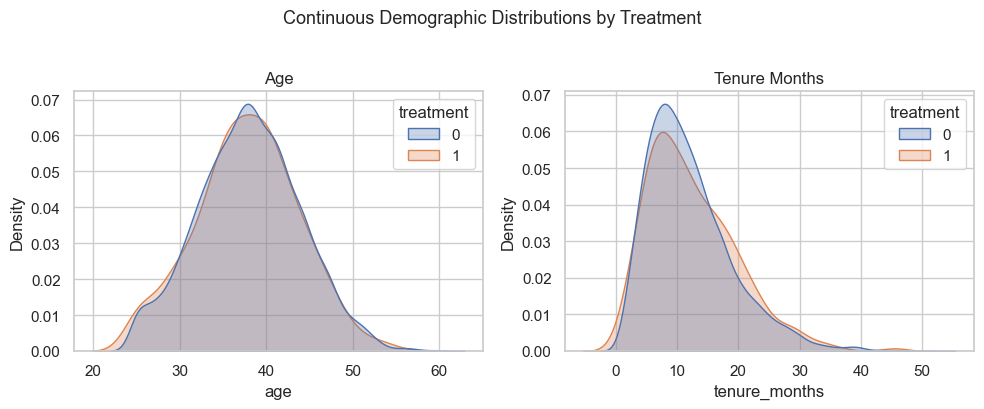

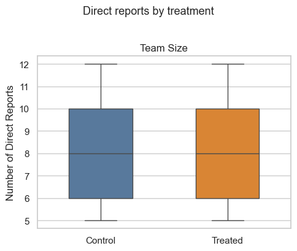

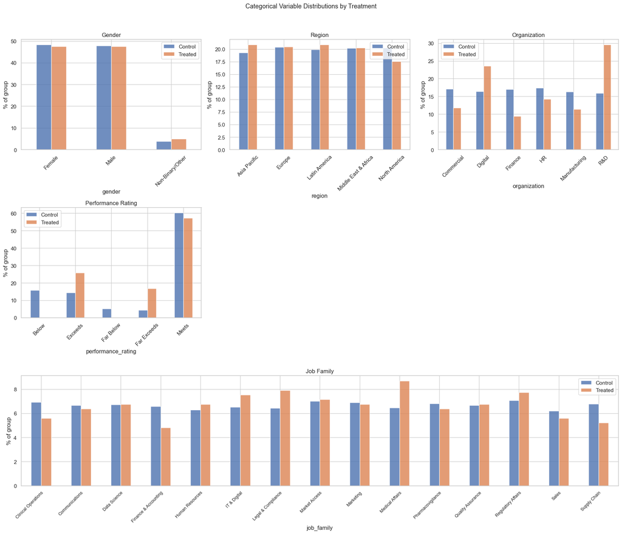

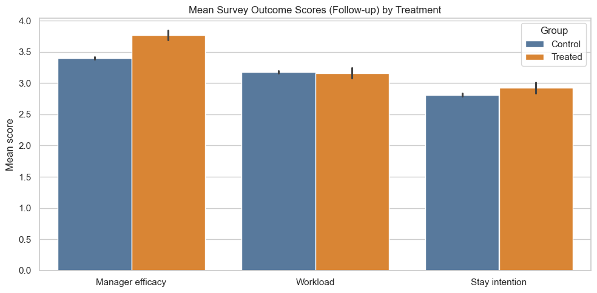

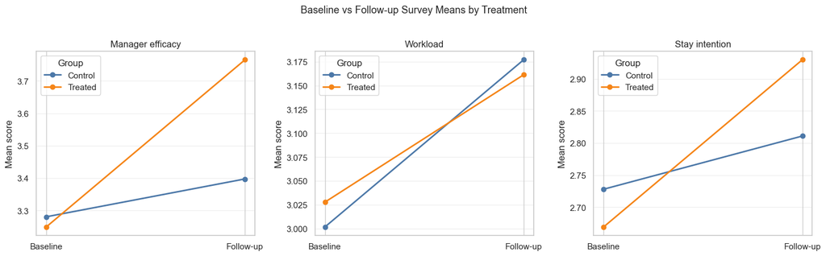

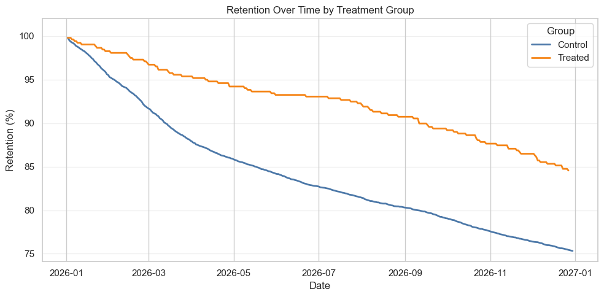

#### Positivity Violation: No Low Performers in the Treated Group

We observe that **zero managers rated "Far Below" or "Below" completed the training program.** This is a **positivity violation** — for this subgroup, the probability of treatment is exactly zero: $P(T=1 \mid \text{performance} \in \{\text{Far Below, Below}\}) = 0$.

This means we **cannot estimate the treatment effect for low performers** because there are no treated low performers to learn from. No statistical method can fix this — it is a fundamental data (program set-up) limitation.

**Our decision:** We exclude low performers from the analysis. This is a defensible response to positivity violations, but it has an important consequence: **our ATE now applies only to average-and-above performers.** If L&D scales this program to include low performers, our estimates are not informative about potential effects for this subgroup.

This is an **estimand-scoping decision**, not a data-cleaning step. It should be documented in any report and flagged as a limitation.

**Is this structural or stochastic?** If low performers were *ineligible* or *discouraged* by design, this is a deliberate eligibility criterion and the ATE is redefined — the program simply has no causal effect to estimate for that subgroup. If zero low-performer uptake instead reflects random sampling variation or soft discouragement, it is a stochastic positivity violation and a larger sample might have non-zero treated. Document which interpretation applies before presenting — they have different implications for program decisions.

```
After exclusion: 7220 managers remain
treatment
0    6702
1     518
dtype: int64

============================================================
POST-EXCLUSION DESCRIPTIVES — Low performers removed
============================================================
============================================================
BASELINE DEMOGRAPHIC & SURVEY COMPARISON: Treated vs Control
============================================================
```

|  | Control | Treated | Diff (T - C) | p-value | Sig. at 95% |
| --- | --- | --- | --- | --- | --- |
| baseline_manager_efficacy | 3.281 | 3.249 | -0.032 | 0.393 |  |
| baseline_workload | 3.004 | 3.028 | 0.024 | 0.568 |  |
| baseline_stay_intention | 2.729 | 2.669 | -0.059 | 0.148 |  |
| age | 38.072 | 37.790 | -0.282 | 0.297 |  |
| tenure_months | 11.947 | 12.498 | 0.551 | 0.098 |  |
| num_direct_reports | 8.532 | 8.429 | -0.103 | 0.329 |  |
| tot_span_of_control | 18.503 | 18.776 | 0.273 | 0.415 |  |

```
------------------------------------------------------------

gender  —  χ² test to determine whether distributions differ among T & C = 2.08, df = 2, p = 0.3527 not significantly
```

| gender | Control % | Treated % | Diff (pp) |
| --- | --- | --- | --- |
| Female | 48.5 | 47.5 | -1.0 |
| Male | 47.8 | 47.5 | -0.3 |
| Non-Binary/Other | 3.8 | 5.0 | 1.3 |

```
region  —  χ² test to determine whether distributions differ among T & C = 3.01, df = 4, p = 0.5559 not significantly
```

| region | Control % | Treated % | Diff (pp) |
| --- | --- | --- | --- |
| Asia Pacific | 19.3 | 20.8 | 1.6 |
| Europe | 20.5 | 20.5 | -0.0 |
| Latin America | 19.7 | 20.8 | 1.1 |
| Middle East & Africa | 20.0 | 20.3 | 0.2 |
| North America | 20.5 | 17.6 | -2.9 |

```
organization  —  χ² test to determine whether distributions differ among T & C = 109.18, df = 5, p = 0.0000 ***
```

| organization | Control % | Treated % | Diff (pp) |
| --- | --- | --- | --- |
| Commercial | 17.3 | 11.8 | -5.5 |
| Digital | 16.1 | 23.6 | 7.4 |
| Finance | 16.9 | 9.5 | -7.4 |
| HR | 17.5 | 14.3 | -3.2 |
| Manufacturing | 16.7 | 11.4 | -5.3 |
| R&D | 15.5 | 29.5 | 14.0 |

```
job_family  —  χ² test to determine whether distributions differ among T & C = 11.95, df = 14, p = 0.6105 not significantly
```

| job_family | Control % | Treated % | Diff (pp) |
| --- | --- | --- | --- |
| Clinical Operations | 6.8 | 5.6 | -1.2 |
| Communications | 6.4 | 6.4 | -0.0 |
| Data Science | 6.5 | 6.8 | 0.2 |
| Finance & Accounting | 6.7 | 4.8 | -1.9 |
| Human Resources | 6.4 | 6.8 | 0.3 |
| IT & Digital | 6.5 | 7.5 | 1.0 |
| Legal & Compliance | 6.5 | 7.9 | 1.4 |
| Market Access | 7.1 | 7.1 | 0.1 |
| Marketing | 6.8 | 6.8 | -0.1 |
| Medical Affairs | 6.5 | 8.7 | 2.2 |
| Pharmacovigilance | 6.8 | 6.4 | -0.4 |
| Quality Assurance | 6.8 | 6.8 | -0.0 |
| Regulatory Affairs | 7.0 | 7.7 | 0.7 |
| Sales | 6.2 | 5.6 | -0.6 |
| Supply Chain | 6.8 | 5.2 | -1.6 |

```
performance_rating  —  χ² test to determine whether distributions differ among T & C = 135.25, df = 2, p = 0.0000 ***
```

| performance_rating | Control % | Treated % | Diff (pp) |
| --- | --- | --- | --- |
| Exceeds | 18.3 | 25.9 | 7.6 |
| Far Exceeds | 5.5 | 16.8 | 11.3 |
| Meets | 76.2 | 57.3 | -18.9 |

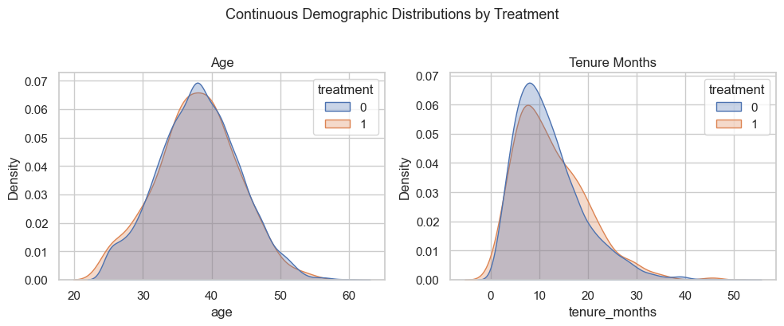

[figure not shown]

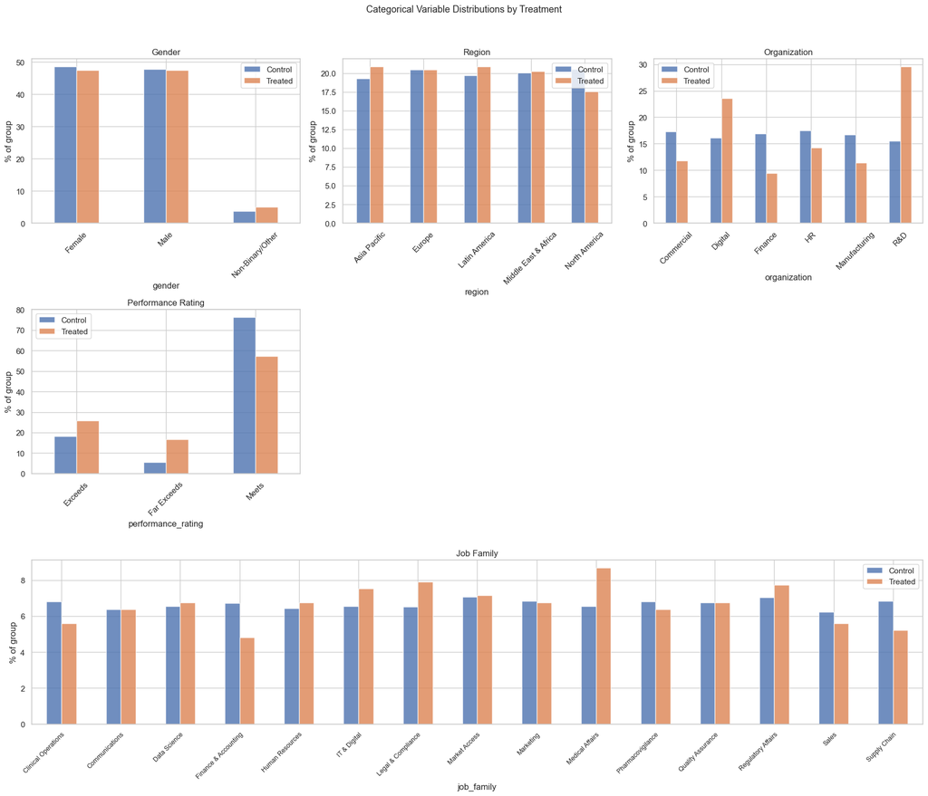

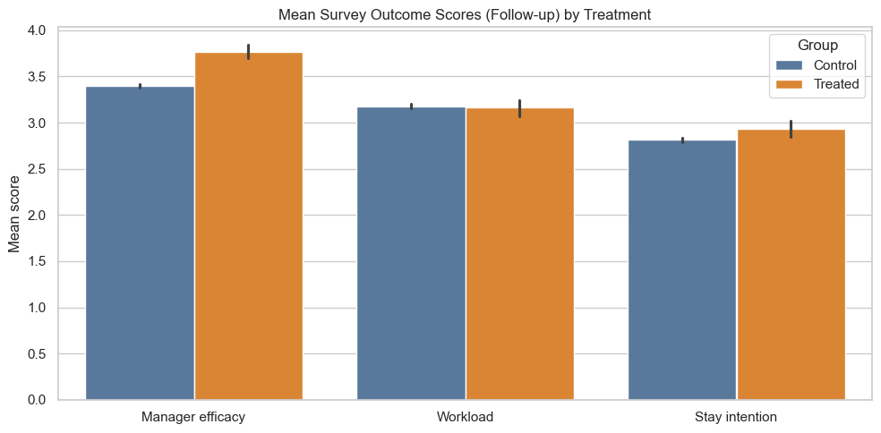

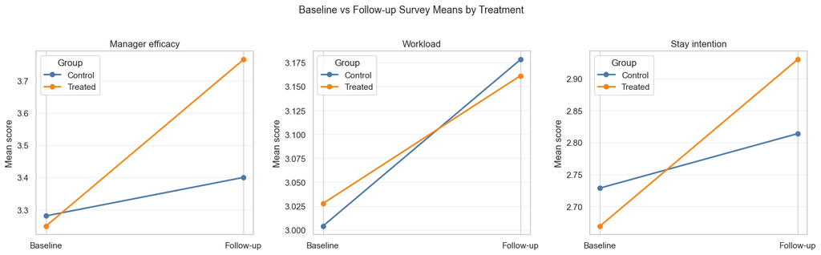

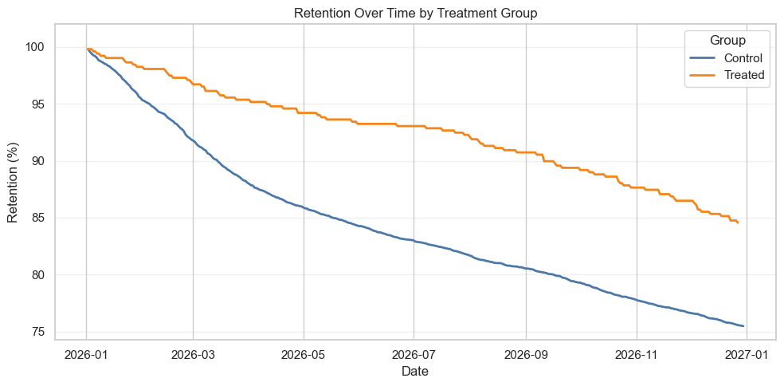

### Summary: Checkpoint 1

[figure not shown]

Checkpoint 1

Research Design & Data Exploration

Achievements

✅ Documented assumptions with a DAG aligned to our research question

✅ Conducted best practice data hygiene checks and exploratory analysis

Key Research Questions

Does manager training impact **self-reported efficacy, workload, or stay intention**? Does it impact **actual retention**?

Takeaways

**Some imbalance** observed between Treatment and Control for Organization.

**Problematic imbalance for performance:** No low-performing managers signed up for training → **low performers removed from analysis population**.

1 / 1

## Checkpoint 2: Diagnostics & Causal Identification Strategy

[figure not shown]

Overview

Choosing Our Estimand: ATE vs ATT

Before we can estimate a causal effect, we need to decide **what effect** we're trying to estimate. The choice depends on our research question and data structure.

Slide 2ATE vs ATT Comparison

Slide 3💬 Discussion: Our Context

Slide 4Our Decision: ATE

Slide 5Side Note: IV Approach

Comparison

ATE vs ATT: Key Differences

| Consideration | ATE | ATT |
| --- | --- | --- |
| **Target population** | Full population (treated + untreated) | Only those who received treatment |
| **Research question** | "What if we rolled this out to everyone?" | "Did it work for those who participated?" |
| **Overlap requirement** | Strict: every covariate profile needs both treated and control | Relaxed: only need controls resembling the treated |
| **Typical use case** | Policy decisions about universal rollout | Evaluating voluntary/targeted programs |
| **When treated group is small** | Problematic — requires extrapolation | Natural fit — only generalizing to treated |

Discussion

💬 Discussion: Thinking Through Our Context

Click each question to reveal the discussion point.

What is L&D's goal with this training program? ▶

- L&D wants to **train as many managers as possible** — they're considering scaling this program

- They need to know: **"Should we roll this out to everyone?"**

- This is a **policy question** about universal implementation, not just about self-selected participants

How did managers end up in the training program? ▶

- **Voluntary participation** — any manager who signed up could attend

- **Uneven promotion** — some departments actively encouraged participation, others sent a single email

- This creates **selection bias** — motivated managers or those in supportive departments are more likely to participate

Which estimand (ATE or ATT) matches our research question? ▶

- **ATE** answers: "What would happen if we *mandated* training for everyone?"

- **ATT** answers: "What happened for those who self-selected into training?"

- **LATE (encouragement)** answers: "What is the effect on those whose participation is swayed by how strongly their org encouraged them?"

- The right choice depends on L&D's *actual* policy plan:

  - If training becomes **mandatory** at scale → **ATE**.

  - If training stays **voluntary** but is rolled out more broadly → **ATT** (effect for those who self-select in) is often more policy-relevant than ATE (which extrapolates to non-takers).

  - If the organization wants to know the effect of *increased encouragement* → **LATE** via IV.

- For this workshop we assume mandatory rollout and estimate **ATE**; the later ATT comparison and the IV side-note provide the alternatives.

Decision

Our Target Estimand: ATE

**Our target estimand: ATE (Average Treatment Effect)**

Since L&D wants to scale training to all managers, we estimate the **population-level effect** — what would happen if we assigned training to everyone vs. no one?

Diagnostic Strategy:

- **Goal:** Determine if our data structure supports estimating ATE

- **If successful:** We can estimate ATE

- **If not:** We can still get useful insights from ATT (effect on self-selected participants)

- **Last resort:** If data doesn't support causal inference, we're limited to descriptive analysis

**Next steps:** We'll conduct diagnostics (overlap, balance, propensity score distribution) to assess whether ATE estimation is feasible with our data.

Side Note

Side Note: Encouragement Design & IV

The department-level variation in how actively the program was promoted resembles a natural **encouragement design**.

Potential IV Approach:

- Departments that encouraged participation more strongly could serve as an **instrument**

- Could estimate **Local Average Treatment Effect (LATE)** for compliers

Why We Won't Pursue This:

The **exclusion restriction is questionable** — departments that actively promoted training likely differ in other ways (stronger learning culture, more supportive leadership, additional resources) that could independently influence outcomes.

*Worth keeping in mind for settings where more credibly exogenous encouragement exists.*

1 / 5

### Diagnostic Prep

```
Survey outcomes:    ['manager_efficacy_index', 'workload_index_mgr', 'stay_intention_index_mgr']
Covariates:         5 categorical, 4 continuous
```

[output not shown]

[output cut: 47 more lines]

```

        # Step 1 — Pre-modeling checks
        cd.check_high_intercorrelations(df)
        cd.check_vif(df, controls=my_controls, treatment='T')
        cd.show_low_proportion_groups(df, treatment='T')

        # Step 2 — Overlap / common support
        overlap = cd.run_overlap_diagnostics(
            df, 'T', outcome_vars, baseline_vars,
            categorical_vars=categorical_vars, binary_vars=binary_vars,
            continuous_vars=continuous_vars)
        cd.save_overlap_diagnostics_summary(overlap, 'overlap_report.txt')

        # Step 3 — After IPW / matching
        cd.compute_balance_df(df, controls, 'T', weights)
```

> ⚠️ **Order of operations for causal inference:** Overlap (positivity) is the *primary* diagnostic — shown in the next section. Multicollinearity / VIF is presented first here for completeness, but **do not drop a true confounder because of high VIF**. Inspect first. For IPTW, collinearity among covariates in the PS model is generally tolerable; the propensity score itself is what matters, not individual coefficients.

### Initial Diagnostics: Multicollinearity/VIF

When you include multiple covariates in a regression model (like the propensity score model), some of them may be highly correlated with each other. Why is it important: Multicollinearity doesn't bias your estimates, but it inflates the standard errors, making it harder to detect real effects and producing unstable coefficient estimates (especially when you work with smaller sample sizes - as usually the case in People Analytics).

| Function | Purpose |
| --- | --- |
| `check_high_intercorrelations` | Flags pairs above threshold (default 0.7) using Pearson, Cramér's V, or η |
| `check_vif` | Assesses multicollinearity via VIF (continuous) and adjusted GVIF (categorical). VIF shows "How well can this variable be predicted by all the other variables in the model?" |

```
============================================================
CHECK 1: INTERCORRELATIONS
============================================================
✅ No highly correlated pairs found.

============================================================
CHECK 2: VARIANCE INFLATION FACTOR (VIF)
============================================================
```

|  | Variable | Type | VIF / GVIF | Adjusted (GVIF^1/2df) | Shared Variance | Severity |
| --- | --- | --- | --- | --- | --- | --- |
| 0 | tot_span_of_control | Continuous | 1.1114 | 1.1114 | <25% of variance is shared | ✅ None |
| 1 | num_direct_reports | Continuous | 1.1062 | 1.1062 | <25% of variance is shared | ✅ None |
| 2 | treatment | Continuous | 1.0385 | 1.0385 | <25% of variance is shared | ✅ None |
| 3 | performance_rating | Categorical (2 dummies) | 1.0297 | 1.0074 | <25% of variance is shared | ✅ None |
| 4 | tenure_months | Continuous | 1.0071 | 1.0071 | <25% of variance is shared | ✅ None |
| 5 | age | Continuous | 1.0063 | 1.0063 | <25% of variance is shared | ✅ None |
| 6 | organization | Categorical (5 dummies) | 1.0312 | 1.0031 | <25% of variance is shared | ✅ None |
| 7 | gender | Categorical (2 dummies) | 1.0074 | 1.0018 | <25% of variance is shared | ✅ None |
| 8 | region | Categorical (4 dummies) | 1.0147 | 1.0018 | <25% of variance is shared | ✅ None |
| 9 | job_family | Categorical (14 dummies) | 1.0340 | 1.0012 | <25% of variance is shared | ✅ None |

### Overlap Diagnostics

[figure not shown]

```
================================================================================
STEP 2: OVERLAP / COMMON SUPPORT DIAGNOSTICS
================================================================================

    This step determines WHICH ESTIMAND (ATT vs ATE) is credible in your data.

    KEY CONCEPTS:
    - ATT (Average Treatment Effect on the Treated): Effect for those who got treatment
    → Requires: Good overlap for TREATED units (each treated has comparable controls)

    - ATE (Average Treatment Effect): Effect if we treated everyone
    → Requires: Good overlap BOTH directions (treated exist across control range too)

    With imbalanced samples, ATT is typically the credible estimand because
    many controls sit in regions where no treated units exist.

    We'll check overlap for each outcome (since adjustment sets include different baselines).

================================================================================
DETAILED DIAGNOSTICS
================================================================================
Checks 1A–1C (continuous, binary, categorical SMDs) are identical
across outcomes. Only baseline check (1D) and propensity-score model
(Check 2) vary by outcome due to outcome-specific baseline variables.
Showing full detail for first outcome: manager_efficacy_index

  Baseline variable 'baseline_manager_efficacy' will be checked separately (CHECK 1D)

Adjustment set for manager_efficacy_index:
  Categorical (5):  ['gender', 'organization', 'job_family', 'performance_rating', 'region']
  Binary      (0):  []
  Continuous  (4): ['age', 'tenure_months', 'num_direct_reports', 'tot_span_of_control']
  Baseline    (1): ['baseline_manager_efficacy']

================================================================================
COVARIATE OVERLAP DIAGNOSTIC
================================================================================

This check determines if treatment and control groups are comparable.
If groups occupy different covariate spaces, causal inference is problematic.
```

[output cut: 160 more lines]

```
    Assessment   : PROCEED (confidence: HIGH)

  workload_index_mgr
    Baseline var : baseline_workload
    AUC: 0.663  |  Treated in overlap: 88.0%  |  Controls in overlap: 93.1%  |  Max |SMD|: 0.402
    Assessment   : PROCEED (confidence: HIGH)

  stay_intention_index_mgr
    Baseline var : baseline_stay_intention
    AUC: 0.664  |  Treated in overlap: 88.6%  |  Controls in overlap: 91.5%  |  Max |SMD|: 0.402
    Assessment   : PROCEED (confidence: HIGH)

================================================================================
SUMMARY TABLE: ESTIMAND RECOMMENDATIONS BY OUTCOME
================================================================================
```

|  | Outcome | AUC | Treated Overlap % | Control Overlap % | Max \|SMD\| (Source) | Baseline Balance | Imbalanced Vars | Estimand | Rationale |
| --- | --- | --- | --- | --- | --- | --- | --- | --- | --- |
| 0 | manager_efficacy_index | 0.662 | 88.6 | 93.2 | 0.402 (performance_rating) | ✓ Good (0.039) | performance_rating (0.40); organization (0.34) | ATE | Strong bidirectional overlap; ATE fully defens... |
| 1 | workload_index_mgr | 0.663 | 88.0 | 93.1 | 0.402 (performance_rating) | ✓ Good (0.026) | performance_rating (0.40); organization (0.34) | ATE | Strong bidirectional overlap; ATE fully defens... |
| 2 | stay_intention_index_mgr | 0.664 | 88.6 | 91.5 | 0.402 (performance_rating) | ✓ Good (0.064) | performance_rating (0.40); organization (0.34) | ATE | Strong bidirectional overlap; ATE fully defens... |

```
================================================================================
INTERPRETATION GUIDE: WHAT THIS MEANS FOR YOUR ANALYSIS
================================================================================

    ╔══════════════════════════════════════════════════════════════════════════════╗
    ║  WHAT IS COVARIATE OVERLAP AND WHY DOES IT MATTER?                           ║
    ╠══════════════════════════════════════════════════════════════════════════════╣
    ║                                                                              ║
    ║  Causal inference requires COMPARABLE treatment and control groups.          ║
    ║  "Comparable" means: for each treated person, there exist control people     ║
    ║  with similar characteristics (covariates) who can serve as counterfactuals. ║
    ║                                                                              ║
    ║  If groups occupy DIFFERENT covariate spaces, we cannot observe what would   ║
    ║  have happened to treated people without treatment — we must EXTRAPOLATE.    ║
    ║                                                                              ║
    ║  Example of POOR overlap:                                                    ║
    ║    Treated: Senior managers, age 45-60, high performers                      ║
    ║    Control: Junior staff, age 25-35, mixed performers                        ║
    ║    → No controls "look like" the treated → must extrapolate → unreliable     ║
    ╚══════════════════════════════════════════════════════════════════════════════╝

    ╔══════════════════════════════════════════════════════════════════════════════╗
    ║  WHAT IS EXTRAPOLATION AND WHY IS IT DANGEROUS?                              ║
    ╠══════════════════════════════════════════════════════════════════════════════╣
    ║                                                                              ║
    ║  EXTRAPOLATION = Predicting outcomes for people UNLIKE anyone in the data.   ║
    ║                                                                              ║
    ║  When we estimate "what would treated person X have scored without           ║
    ║  treatment?", we use control group data. But if no controls are similar      ║
    ║  to person X, we're guessing based on dissimilar people.                     ║
    ║                                                                              ║
    ║  Visual example:                                                             ║
    ║                                                                              ║
    ║  Control data:     [●●●●●●●●]                                                ║
    ║  Treated person:                    [X]                                      ║
    ║                    ↑_______________↑                                         ║
    ║                    We have data    No data here — must extrapolate!          ║
    ║                                                                              ║
    ║  The further X is from observed controls, the more uncertain our estimate.   ║
    ╚══════════════════════════════════════════════════════════════════════════════╝
```

[output cut: 97 more lines]

```


================================================================================
OVERALL STEP 2 SUMMARY: ESTIMAND SELECTION GUIDANCE
================================================================================

    ✓ EXCELLENT OVERLAP: Strong bidirectional overlap across all outcomes.

    RECOMMENDED ESTIMAND: ATE (Average Treatment Effect)
        Both groups are well-represented — ATE is fully defensible.

    NEXT STEPS:
        • IPTW with stabilized weights is appropriate
        • IPTW plus covariate adjustment adds further protection
        • Compare ATE and ATT estimates as a robustness check
```

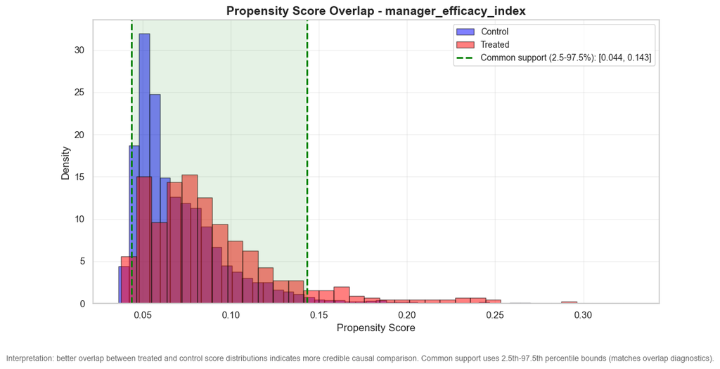

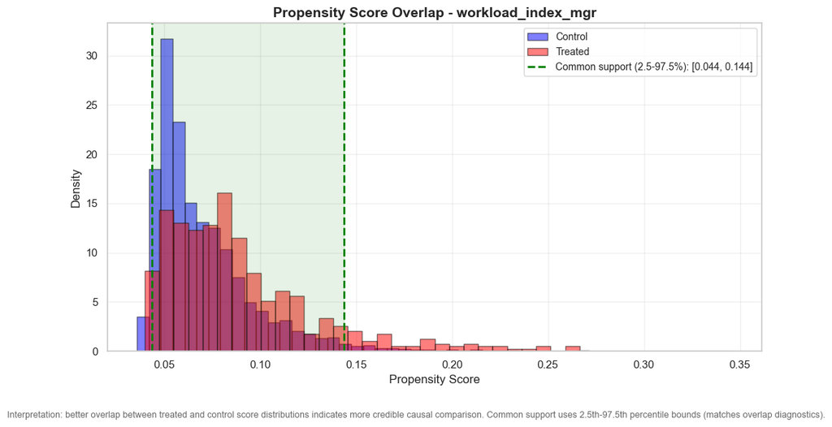

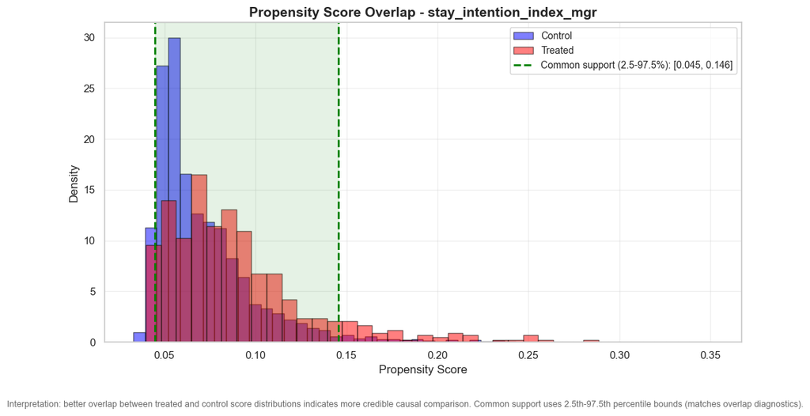

```
✓ Diagnostics summary saved to: c:\Users\U1013877\OneDrive - Sanofi\Documents\GitHub\2026-siop-causal-inference-master-tutorial\results\overlap_diagnostics_summary.txt
```

### Summary: Checkpoint 2

[figure not shown]

Checkpoint 2

Diagnostics & Causal Identification

Achievements

✅ Determined our estimand of interest

✅ Conducted diagnostics to assess credibility of causal inference and identify model stabilization strategies

Takeaways

After removing untreated low-performer controls, all diagnostics support a **reasonable ATE estimate**.

**No concerning multicollinearity.**

**AUC < 0.7** with ~90% overlap in both directions — observed covariates do not strongly predict treatment. This is a **necessary but not sufficient** condition for valid IPTW adjustment. Unobserved confounding is still possible and is addressed via E-value sensitivity analysis later in the workflow.

1 / 1

## Checkpoint 3: Survey Modeling

[figure not shown]

Overview

Survey Outcomes — IPTW + GEE: Estimating ATE

Use this approach when treatment is **not purely randomized**, propensity scores are **well-distributed**, and weighted SMDs are **acceptable**. Our approach uses **two complementary models**:

Slide 2📌 Note on Estimand: ATE vs ATT

Model 1: Propensity Score → IPTW Purpose: Balance treatment groups on observed confounders

Slide 3Propensity Score Model

Slide 4Converting to ATE Weights

Slide 5💬 Discussion: Weight Intuition

Slide 6Stabilizing & Trimming Weights

Slide 7💬 Discussion: Extreme Weights

Model 2: Outcome Model → GEE Purpose: Estimate treatment effect on balanced data

Slide 8Weighted GEE Model

Slide 9💬 Discussion: Why GEE?

Slide 10Continuous Outcome (Identity Link)

Slide 11Partial Robustness

Slide 12Additional Assumptions

Estimand

Note on Estimand: ATE vs ATT

**GEE is agnostic to the estimand** — it simply fits a weighted regression with cluster-robust standard errors. Whether you estimate the **ATE** or the **ATT** is determined entirely by how the weights are constructed. This implementation uses **ATE weights**, which reweigh both treated and control groups to represent the full population.

Let:

- \(Y_i\) = outcome for individual \(i\)

- \(Treatment_i\) = 1 if participated, 0 otherwise

- \(X_i\) = pre-treatment individual-level covariates

- \(Team_i\) = direct manager's team (used for clustering)

As a rule of thumb, it is recommended to have at least **30–50 clusters**. For fewer clusters, consider bootstrapping standard errors.

Model 1: IPTW

Step 1: The Propensity Score Model

The first stage estimates the **propensity score** — the probability of receiving treatment given observed covariates.

\[ \text{logit}(e_i) = \log\left(\frac{e_i}{1-e_i}\right) = \alpha_0 + \alpha_1 X_i \]

Where:

- \(e_i = P(Treatment_i = 1 \mid X_i)\) = propensity score for individual \(i\)

- \(X_i\) = vector of pre-treatment covariates (same covariates used in outcome model)

- Fitted using **logistic regression** with all individuals in the dataset

**Key insight:** We're modeling the **treatment assignment mechanism** — what factors predict who received training vs. who didn't? This allows us to identify individuals who were "unlikely" to receive the treatment they actually got.

Model 1: IPTW

Step 2: Converting Propensity Scores to ATE Weights

Once we have propensity scores \(\hat{e}_i\), we convert them to **ATE weights**:

\[ w_i = \begin{cases} \frac{1}{\hat{e}_i} & \text{if treated} \\ \frac{1}{1-\hat{e}_i} & \text{if control} \end{cases} \]

Intuition:

- **Treated individuals with low \(\hat{e}_i\)** (unlikely to be treated) get **high weights**

- **Control individuals with high \(\hat{e}_i\)** (likely to be treated) get **high weights**

- This creates a **"pseudo-population"** where treatment assignment appears random

Discussion

💬 Discussion: Understanding Weight Intuition

Click each question to reveal the discussion point.

Why do we upweight some people and downweight others? ▶

- We're creating a **"pseudo-population"** where treatment looks random

- People who got treatment despite being **unlikely** to get it are rare/valuable → upweight them

- People who were **very likely** to get treatment anyway are common → downweight them

- This rebalances the groups so they're comparable on observed confounders

What happens if someone has a propensity score of 0.95 (very likely to be treated)? ▶

- **If treated:** weight = 1/0.95 ≈ 1.05 (close to 1, minimal adjustment needed)

- **If control:** weight = 1/0.05 = 20 (huge weight! They're very informative)

- This person in the control group is **"surprising"** — they tell us a lot about what happens when high-propensity people don't get treatment

- Conversely, someone with \(\hat{e}_i = 0.05\) who ends up in control gets weight ≈ 1.05, but if treated gets weight = 20

Why is this better than just matching treated to similar controls? ▶

- **Uses all the data** — no discarding observations (matching often throws away unmatched controls)

- **Weights create balance** across the entire covariate distribution, not just matched pairs

- **More efficient** — retains more information and statistical power

- **More generalizable** — estimates apply to the full population, not just the matched subset

Model 1: IPTW

Step 3: Stabilizing and Trimming Weights

Stabilized Weights

Multiply by marginal treatment probability \(\bar{p}\) to reduce variance:

\[ w_i^{stab} = \begin{cases} \frac{\bar{p}}{\hat{e}_i} & \text{if treated} \\ \frac{1-\bar{p}}{1-\hat{e}_i} & \text{if control} \end{cases} \]

Weight Trimming

Cap extreme weights at a specified quantile (e.g., 99th percentile):

- **Problem:** Individuals with \(\hat{e}_i\) near 0 or 1 get extreme weights

- **Solution:** Set maximum weight threshold to prevent any single observation from dominating

- **Trade-off:** Small bias for substantially reduced variance

Stabilized weights have mean ≈ 1 and are less variable than raw weights, making the analysis more stable while preserving the balance properties.

Discussion

💬 Discussion: Dealing with Extreme Weights

Click each question to reveal the discussion point.

What's the problem with extreme weights? ▶

- One person with weight = 50 **dominates** 50 people with weight = 1

- **High variance** → unstable estimates that change dramatically with small data changes

- Often indicates **positivity violations** — some people had near-zero chance of their actual treatment

- A single outlier can drive your entire result

When should we trim weights vs. when should we worry about our data? ▶

- **Trim:** A few outliers due to sampling variability (e.g., cap at 99th percentile)

- **Worry:** Many extreme weights suggest fundamental overlap problems → consider **ATT instead of ATE**

- **Check:** Plot weight distributions before and after trimming to diagnose the issue

- If most weights are extreme, your data may not support ATE estimation

What's the trade-off with stabilized weights? ▶

- **Pro:** Much more stable, mean ≈ 1, easier to interpret

- **Pro:** Reduces influence of extreme propensity scores

- **Con:** Slight bias if marginal treatment probability is misestimated

- **In practice:** Almost always worth it — the variance reduction far outweighs the small bias

Model 2: GEE

Step 4: The Weighted GEE Outcome Model

Now we use the IPTW weights in a **Generalized Estimating Equation** to estimate the treatment effect:

\[ g\big(E[Y_i]\big) = \beta_0 + \beta_1 \cdot Treatment_i + \beta_2 \cdot X_i \]

Where:

- \(g(\cdot)\) = link function (identity for continuous, logit for binary outcomes)

- Each observation weighted by \(w_i^{stab}\) from the propensity score model

- Clustering at the **team level** (by direct manager ID)

- **Exchangeable working correlation** within teams

- **Robust sandwich standard errors** account for correlation and weight uncertainty

**Key insight:** GEE fits a population-averaged model using the reweighted data. The weights ensure that treated and control groups are balanced on observed confounders, mimicking a randomized experiment.

Discussion

💬 Discussion: Why GEE Instead of Regular Regression?

Click each question to reveal the discussion point.

Why not just use weighted OLS regression? ▶

- Managers on the same team **aren't independent** — they share a leader, team culture, resources

- Standard errors from OLS would be **too small** (overconfident) because they assume independence

- GEE accounts for **within-team correlation** with robust sandwich standard errors

- Ignoring clustering can lead to false positives (claiming significance when there isn't any)

What does "exchangeable correlation" mean for our teams? ▶

- Assumes **any two managers on the same team are equally correlated**

- Reasonable if team culture/leader effects are **shared uniformly** across team members

- **Alternative structures:** independent (ignores clustering), unstructured (estimates all pairwise correlations), autoregressive (time-ordered)

- Exchangeable is a good default for cross-sectional team data

Why do we need "sandwich" standard errors? ▶

- **Protects against misspecification** of the correlation structure — even if exchangeable is wrong, SEs are still valid

- Accounts for the fact that **weights are estimated** (though not perfectly — bootstrap for full uncertainty)

- Makes inference **robust** even if our working correlation assumption is incorrect

- Called "sandwich" because it sandwiches the model-based variance between empirical variance estimates

Why choose GEE over WLS with cluster-robust standard errors? ▶

- **Generalizes to mixed outcomes:** handles both continuous scales and binary flags (like retention) in one framework

- **Literature alignment:** standard approach in causal inference and marginal structural models

- **Future-proofing:** extends naturally to longitudinal data with repeated measures

- **Note:** For our cross-sectional data, GEE and WLS with cluster-robust SEs produce nearly identical results

Model 2: GEE

Continuous Outcome (Identity Link)

\[ E[Y_i] = \beta_0 + \beta_1 \cdot Treatment_i + \beta_2 \cdot X_i \]

- \(\beta_1\) = **ATE**: the weighted average difference in outcomes between treated and control individuals, after reweighting to balance observed confounders

- **Interpretation:** on average across the population, treatment shifts the outcome by \(\beta_1\) units

GEE sandwich standard errors account for within-team correlation but do **not** propagate uncertainty from the first-stage propensity score estimation. For stricter inference, consider a non-parametric bootstrap that re-estimates both stages in each replicate.

Model 2: GEE

Partial Robustness via Nested Adjustment

Using the same pre-treatment covariates in *both* the propensity score model and the outcome model provides partial protection against misspecification — if one model is somewhat off, the other often compensates.

**This is *not* formal double robustness.** Formal double robustness (the estimator is consistent if *either* the PS or the outcome model is correctly specified) is a property of **AIPW** and **TMLE** estimators, whose score functions are Neyman-orthogonal. Standard IPTW + weighted outcome regression does not carry that guarantee. The **Double Machine Learning** bonus section at the end of this notebook is an example of a formally robust estimator.

In either case, both models share the same main-effects-only functional form, so misspecification (e.g., missing interactions) affects both simultaneously. This is a **safeguard, not a guarantee**.

Model 2: GEE

Additional Required Assumptions

Two assumptions are always required regardless of model correctness:

- **Positivity (overlap):** Every individual must have a non-zero probability of receiving either treatment or control: \[0 < P(Treatment_i = 1 \mid X_i) < 1 \text{ for all } i\] Violations (propensity scores near 0 or 1) produce extreme weights and unstable estimates.

- **Correct temporal ordering:** All covariates \(X_i\) must be measured **prior to** treatment assignment to qualify as true pre-treatment confounders. Including post-treatment variables as covariates can introduce bias.

1 / 12

Overview

Summary: Model Design Choices

This section walks through each design choice in the IPTW + GEE pipeline, organized by the problem each solves. Click any item below to jump to that section.

Slides 2–3 · Why IPTW?Why Weighting Over Regression Adjustment

Slides 4–6 · WeightingIPTW, ATE Weights, Stabilized Weights

Slide 7 · Variance ControlWeight Trimming & Clipping

Slide 8 · ClusteringGEE Clustering

Slide 9 · RobustnessSandwich Standard Errors

Slide 10 · Model RobustnessIPTW + Covariate Adjustment

Slide 11 · InferenceMultiple Testing Correction (FDR)

Why IPTW?

Why Weighting Instead of Regression Adjustment?

A natural question: why not simply run `outcome ~ treatment + covariates` with OLS? Both approaches aim to adjust for confounders, but they differ in fundamental ways.

| Dimension | IPW | Multivariate Regression |
| --- | --- | --- |
| **Outcome model assumptions** | + No parametric assumptions on the potential outcomes or treatment response function | − Requires a parametric assumption on the conditional expectation (e.g., linearity), effectively assuming specific smoothness in potential outcomes |
| **Positivity transparency** | + Violations are immediately visible: plot the propensity score distribution and see where overlap fails | − Silently extrapolates into covariate regions with no observations from one group — violations are hidden |
| **What ATE it estimates** | + Weights each unit equally (by 1/PS), targeting the population ATE directly | − Weights subgroup effects by conditional variance of treatment — artificially upweights groups where treatment assignment varied most |
| **Design/analysis separation** | + Balance can be verified *before* looking at outcomes (see overlap diagnostics in Checkpoint 2) | − Confounding adjustment and effect estimation happen simultaneously — no independent verification |

Why IPTW?

When Regression Has the Advantage

Regression's strengths

- **Efficiency:** With baseline measures of the same outcome (which we have), ANCOVA-style regression directly absorbs within-subject variance and typically produces tighter confidence intervals

- **Simplicity:** Easier to explain and implement; fewer moving parts that can go wrong

- **Continuous treatments:** For continuous treatment variables, regression is often preferred — IPW's lack of parametric assumptions becomes a drawback when there are very few data points around specific treatment values

Our decision

We use **IPTW + covariate-adjusted GEE**, which combines both approaches:

- IPW handles confounding adjustment nonparametrically

- Covariate adjustment in the outcome model captures residual variance (especially via baseline measures)

- This covariate adjustment improves precision and reduces residual imbalance after weighting (particularly because weights were winsorized), but **should not be interpreted as formally doubly robust** — see Slide 10

**Key context:** Our treatment is binary (participated vs. didn't), treatment probability varies substantially across subgroups (see propensity score distributions), and we have strong baseline measures. This combination favors IPTW with covariate adjustment over pure regression.

Weighting

IPTW — Inverse Probability of Treatment Weighting

Problem It Solves

Treatment assignment is non-random; treated and control groups differ on observed confounders.

Example

Individuals who volunteered for training differ systematically from those who didn't (e.g., higher baseline performance, more tenure).

What It Does

Reweights observations so treated and control groups have balanced covariate distributions, mimicking randomization.

- **Upweights** individuals who were unlikely to receive the treatment they got

- **Downweights** those who were likely to receive it

Weighting

ATE Weights

Problem It Solves

You want to estimate the effect of treatment across the **full population**, not just those who were treated.

Example

Deciding whether to mandate a program for all individuals.

What It Does

Reweights **both** treated and control groups to represent the full population:

- Treated: \(w_i = 1/\hat{e}_i\)

- Control: \(w_i = 1/(1-\hat{e}_i)\)

**Contrast with ATT weights:** leave treated unweighted and reweight controls as \(w_i = \hat{e}_i / (1 - \hat{e}_i)\) to match the treated group's covariate distribution.

Weighting

Stabilized Weights

Problem It Solves

Extreme weights from rare propensity scores cause high variance and unstable estimates.

Example

An individual with PS = 0.02 gets weight = 1/0.02 = 50, dominating the analysis.

What It Does

Multiplies weights by the marginal treatment probability \(\bar{p}\), reducing the range of weight values while preserving balance:

- Treated: \(w_i^{stab} = \bar{p} \;/\; \hat{e}_i\)

- Control: \(w_i^{stab} = (1 - \bar{p}) \;/\; (1 - \hat{e}_i)\)

Stabilized weights have mean ≈ 1 instead of being highly variable.

Variance Control

Weight Trimming & Propensity Score Clipping

Weight Trimming — Problem

A few individuals with extreme propensity scores produce outlier weights that destabilize estimates.

Example

One person with PS = 0.001 gets weight = 1000, overwhelming all other observations.

What It Does

Caps weights at a specified quantile (e.g., 99th percentile). Trades a small bias for substantially reduced variance.

Best practice: check weight distributions and effective sample size to validate the trim threshold — defaults may not be optimal for your sample.

PS Clipping — Problem

Division by propensity scores near 0 or 1 produces infinite or undefined weights.

Example

PS = 0.0000001 → weight = 10,000,000.

What It Does

Clips propensity scores to a safe range (e.g., [0.000001, 0.999999]) before calculating weights. Prevents numerical overflow and extreme weight values.

Clustering

GEE Clustering

Problem It Solves

Observations within groups (teams) are not independent; teammates share common shocks and environments.

Example

Individuals under the same manager have correlated outcomes due to shared leadership style, team culture, and workload.

What It Does

Models within-cluster correlation structure and adjusts coefficient estimation accordingly:

- Produces **population-averaged (marginal) effects** rather than cluster-specific effects

- Prevents **underestimation of standard errors**

- Clustering specified at the **team level** (by direct manager ID)

Rule of thumb: at least 30–50 clusters recommended. For fewer clusters, consider bootstrapping standard errors.

Robustness

Sandwich (Robust) Standard Errors

Problem It Solves

Model assumptions about variance structure may be wrong (heteroskedasticity, misspecified correlation).

Example

You assumed exchangeable correlation within teams, but the true correlation structure is more complex.

What It Does

Uses observed residuals to empirically estimate the true variance, producing standard errors that are valid even if variance assumptions are violated.

- Makes GEE **robust to misspecification** of the working correlation structure

SEs do **not** account for first-stage propensity score estimation uncertainty. Consider cluster bootstrap for fully valid inference.

Model Robustness

IPTW + Covariate Adjustment

What We Did

We estimated IPTW-weighted outcome models that additionally adjusted for the covariates used in the propensity score model.

This covariate adjustment was included to **improve precision** and **reduce residual imbalance** after weighting, particularly because weights were winsorized.

Why include covariates in both stages?

- **Stage 1 — Propensity model:** covariates determine the IPTW weights

- **Stage 2 — Outcome model:** covariates (including baselines) absorb residual variance and correct for any imbalance remaining after winsorization

Important clarification

This approach **should not be interpreted as formally doubly robust**. A formally doubly robust estimator (e.g., AIPW or TMLE) has the specific mathematical property that it yields a consistent estimate if *either* the propensity model or the outcome model is correctly specified. Our IPTW + GEE pipeline does not satisfy that formal guarantee.

**What we gain:** IPW provides nonparametric confounding adjustment; covariate adjustment adds efficiency from baseline measures and corrects for residual imbalance from winsorization. The combination is stronger than either alone, but is not formally doubly robust.

**Note for future iterations:** For Manager Efficacy, the DML PLR estimate (see "Alternative ATE Estimation via Linear DML") already serves as a doubly robust comparator. For Workload, Stay Intention, and Retention, consider adding a formally doubly robust estimator (e.g., AIPW or TMLE) as a sensitivity analysis to verify robustness to specification choice.

Inference

Multiple Testing Correction (FDR)

Problem It Solves

Testing multiple outcomes inflates the Type I error rate (false positives).

Example

Testing 7 outcomes at α = 0.05 gives ~30% chance of at least one false positive under the null.

What It Does

Applies **Benjamini-Hochberg FDR correction** across all p-values within an outcome family.

- Controls the expected proportion of **false discoveries** among rejected hypotheses

- Applied **across outcomes**

1 / 11

#### Run the GEE Model

```
============================================================
ANALYZING OUTCOME: manager_efficacy_index
============================================================

📊 Analyzing outcome: manager_efficacy_index
⚠️  REMINDER: This returns raw p-values. For multiple outcomes, use build_summary_table() for FDR correction.
```

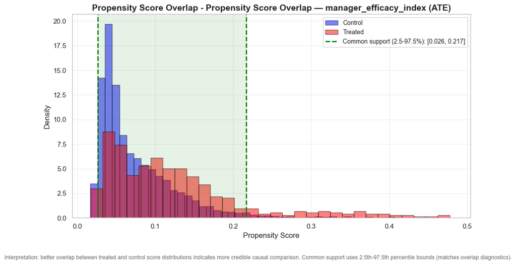

```
  ✓ Post-weighting balance: all 32 covariates balanced (|SMD| < 0.1)
  [manager_efficacy_index] ATE = 0.3975 (95% CI: [0.3222, 0.4729]), p = 0.0000 ***, IPTW-weighted Cohen's d = 0.4732
```

|  | Parameter | Estimate | Std_Error | CI_Lower | CI_Upper | P_Value_Raw | Alpha |
| --- | --- | --- | --- | --- | --- | --- | --- |
| 28 | treatment | 0.397538 | 0.038435 | 0.322208 | 0.472868 | 4.491232e-25 | 0.05 |

```
============================================================
ANALYZING OUTCOME: workload_index_mgr
============================================================

📊 Analyzing outcome: workload_index_mgr
⚠️  REMINDER: This returns raw p-values. For multiple outcomes, use build_summary_table() for FDR correction.
```

[output not shown]

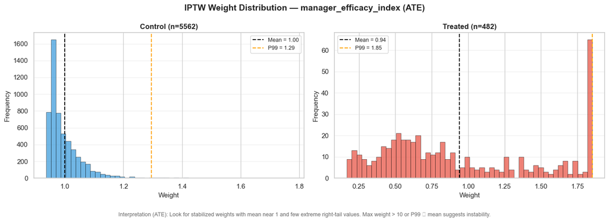

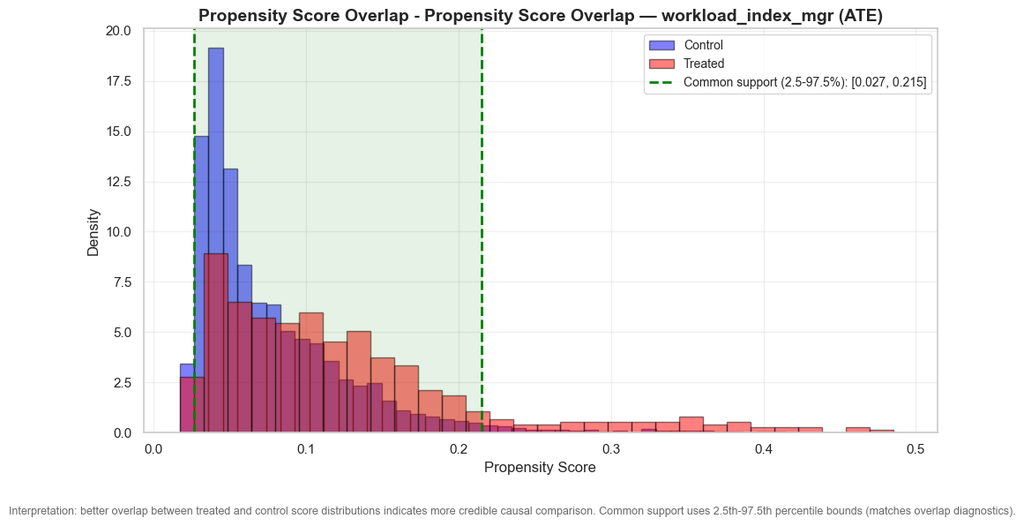

```
  ✓ Post-weighting balance: all 32 covariates balanced (|SMD| < 0.1)
  [workload_index_mgr] ATE = -0.0085 (95% CI: [-0.1015, 0.0844]), p = 0.8572 , IPTW-weighted Cohen's d = -0.0054
```

|  | Parameter | Estimate | Std_Error | CI_Lower | CI_Upper | P_Value_Raw | Alpha |
| --- | --- | --- | --- | --- | --- | --- | --- |
| 28 | treatment | -0.008533 | 0.047433 | -0.101501 | 0.084435 | 0.857242 | 0.05 |

```
============================================================
ANALYZING OUTCOME: stay_intention_index_mgr
============================================================

📊 Analyzing outcome: stay_intention_index_mgr
⚠️  REMINDER: This returns raw p-values. For multiple outcomes, use build_summary_table() for FDR correction.
```

[output not shown]

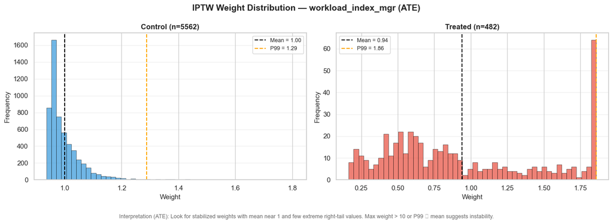

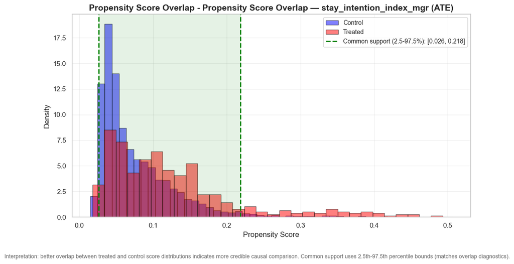

```
  ✓ Post-weighting balance: all 32 covariates balanced (|SMD| < 0.1)
  [stay_intention_index_mgr] ATE = 0.1731 (95% CI: [0.0841, 0.2622]), p = 0.0001 ***, IPTW-weighted Cohen's d = 0.1635
```

|  | Parameter | Estimate | Std_Error | CI_Lower | CI_Upper | P_Value_Raw | Alpha |
| --- | --- | --- | --- | --- | --- | --- | --- |
| 28 | treatment | 0.173146 | 0.045452 | 0.084061 | 0.26223 | 0.000139 | 0.05 |

```
============================================================
  IPTW + GEE: ATE Summary — Survey Outcomes (3 tests)
============================================================
                 Outcome  Effect Estimand Std_Error CI_Lower CI_Upper P_Value Cohens_d Pct_Change Mean_Treatment Mean_Control    N    ESS P_Value_Corrected  Significant Significance Correction_Method
  manager_efficacy_index  0.3975      ATE    0.0384   0.3222   0.4729  0.0000   0.4732     11.75%         3.7982       3.3989 6044 5880.8            0.0000         True          ***            fdr_bh
      workload_index_mgr -0.0085      ATE    0.0474  -0.1015   0.0844  0.8572  -0.0054     -0.16%         3.1735       3.1787 6044 5880.5            0.8572        False                         fdr_bh
stay_intention_index_mgr  0.1731      ATE    0.0455   0.0841   0.2622  0.0001   0.1635      5.58%         2.9647       2.8081 6044 5880.1            0.0002         True          ***            fdr_bh
============================================================
  Significance: *** p<0.001, ** p<0.01, * p<0.05
  Cohens_d: IPTW-weighted Cohen's d (from analyze_treatment_effect)
  Correction: fdr_bh across 3 outcomes

  Summary table saved to c:\Users\U1013877\OneDrive - Sanofi\Documents\GitHub\2026-siop-causal-inference-master-tutorial\results\ate_summary_survey.xlsx
============================================================
BALANCE VERIFICATION — Survey Outcomes (ATE)
============================================================
  ✅ [manager_efficacy_index]  Independent imbalanced: 0  |  Model imbalanced: 0
  ✅ [workload_index_mgr]  Independent imbalanced: 0  |  Model imbalanced: 0
  ✅ [stay_intention_index_mgr]  Independent imbalanced: 0  |  Model imbalanced: 0
```

[output not shown]

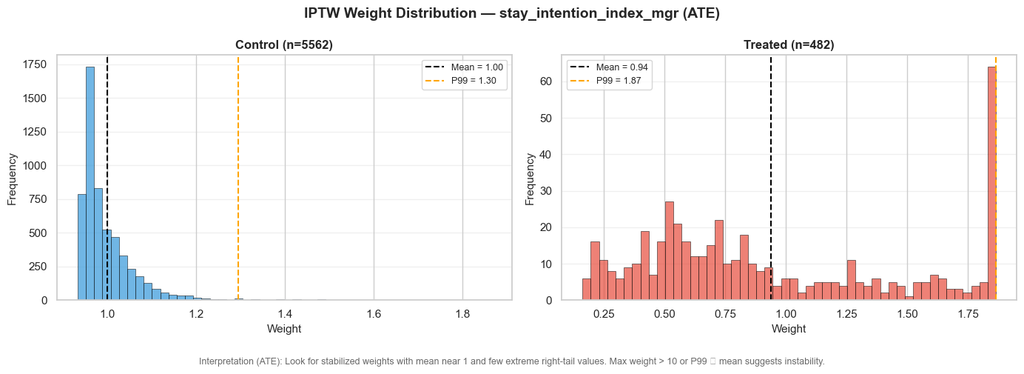

##### Sensitivity Analysis

Overview

Sensitivity Analysis: E-Values and Unmeasured Confounding

Even with IPTW and covariate adjustment, we cannot rule out unmeasured confounding. Sensitivity analysis quantifies how robust our causal estimates are to hidden confounders.

Click any section below to jump to it:

Slide 2The Problem: Unmeasured Confounding

Slide 3What Are E-Values?

Slide 4E-Value Interpretation Scale

Slide 5How to Read E-Value Output

Slide 6Confounder Benchmarking

Slide 7When to Trust Your Results

Problem

The Problem: Unmeasured Confounding

Our causal inference approach (IPTW + GEE) assumes we have measured all confounders. But in reality:

- Some confounders are **unobservable** (e.g., manager motivation, hidden selection bias)

- Some confounders are **unmeasured** in our dataset (e.g., prior training history)

- We can never be 100% certain we've captured everything

The Question:

**"How strong would an unmeasured confounder need to be to explain away our treatment effect?"**

If the answer is "unrealistically strong," we can be more confident in our result. If the answer is "quite modest," we should be cautious.

This is why sensitivity analysis is essential. It acknowledges the limits of our causal assumptions and quantifies the vulnerability of our estimates.

Concept

What Are E-Values?

An **E-value** (Ding & VanderWeele, 2016) is the **minimum strength of association** (on the risk ratio scale) that an unmeasured confounder would need to have with **both treatment and outcome** to explain away a causal effect.

In Plain Language:

- We observe a treatment effect

- The E-value tells us: **"How strong would a hidden confounder need to be to make this effect disappear?"**

- Strength is measured as a **risk ratio (RR)** — the ratio of odds/probabilities

- An E-value of 2.0 means the confounder would need RR = 2.0 with both treatment and outcome

Key Assumption:

E-values assume the confounder affects treatment and outcome **equally** (on the RR scale). This is conservative — a confounder that affects one more than the other would need to be even stronger to explain away the effect.

Interpretation

E-Value Interpretation Scale

E-values are interpreted using heuristic thresholds. Higher E-values = more robust to unmeasured confounding:

**E-value ≥ 3.0:** Strong robustness. A confounder would need RR ≥ 3.0 with both treatment and outcome. This is a high bar — most real confounders are weaker.

**E-value 2.0–3.0:** Moderate robustness. A confounder of moderate strength could potentially explain the effect, but it would need to be fairly strong.

**E-value 1.5–2.0:** Weak robustness. A relatively modest confounder (RR ≈ 1.5–2.0) could explain the effect. Interpret with caution.

**E-value < 1.5:** Very weak robustness. Even a weak confounder could explain the effect away. The result is fragile.

**Caveat:** For continuous outcomes, E-values use an approximate conversion from Cohen's d to RR. The interpretation is approximate, not exact. For binary outcomes, E-values are more precise.

Output

How to Read E-Value Output

E-value analyses typically report two key numbers:

1. Point Estimate E-Value

- Based on the **point estimate** of the treatment effect

- Answers: "How strong must a confounder be to explain away the observed effect?"

- Usually the primary focus

2. Confidence Interval Bound E-Value

- Based on the **lower confidence interval bound** of the treatment effect

- Answers: "How strong must a confounder be to shift the CI to include the null?"

- More conservative — accounts for uncertainty in the estimate

- If this E-value is low, even modest confounding could make the result non-significant

**Practical rule:** If the CI bound E-value is high, your result is robust even accounting for estimation uncertainty. If it's low, be cautious about over-interpreting the result.

Benchmarking

Confounder Benchmarking: Calibration

To interpret E-values in context, we compare them to the **strength of measured confounders** in our data.

The Idea:

- We can calculate E-values for the **strongest measured confounders** (pre-weighting)

- These give us a **benchmark** for what "strong" means in our specific dataset

- If the treatment E-value exceeds the measured confounder E-values, the effect is likely robust

- If the treatment E-value is lower, an unmeasured confounder of similar strength to measured ones could explain the effect

Interpretation:

- **Treatment E-value > Measured confounder E-values:** Effect is robust. An unmeasured confounder would need to be stronger than the measured ones.

- **Treatment E-value ≤ Measured confounder E-values:** Effect is vulnerable. An unmeasured confounder of similar strength to measured ones could explain it away.

Summary

When to Trust Your Results: A Decision Framework

High Confidence (Trust the Result):

- E-value ≥ 3.0 (strong robustness)

- CI bound E-value is also high (≥ 2.0)

- Treatment E-value exceeds measured confounder E-values

Moderate Confidence (Interpret Cautiously):

- E-value 2.0–3.0 (moderate robustness)

- CI bound E-value is moderate (1.5–2.0)

- Treatment E-value is similar to or slightly exceeds measured confounders

Low Confidence (Be Very Cautious):

- E-value < 2.0 (weak robustness)

- CI bound E-value is low (< 1.5)

- Treatment E-value is lower than measured confounder E-values

- **Action:** Seek replication, additional robustness checks, or qualitative evidence

**Remember:** Sensitivity analysis is not a pass/fail test. It's a tool for understanding the vulnerability of your estimates. Even results with low E-values can be valuable — they just require more cautious interpretation and additional evidence.

1 / 7

```
======================================================================
E-VALUE SENSITIVITY ANALYSIS — Survey Outcomes (ATE)
======================================================================

======================================================================
  E-VALUE SENSITIVITY ANALYSIS
======================================================================
                 Outcome Effect_Type  Effect_Value  Effect_RR  E_Value_Point  E_Value_CI Robustness      P_Value  Significant
  manager_efficacy_index    cohens_d      0.473187   1.538181       2.448026    2.182215   Moderate 4.491232e-25         True
      workload_index_mgr    cohens_d     -0.005388   1.004915       1.075196    1.432807  Very Weak 8.572423e-01        False
stay_intention_index_mgr    cohens_d      0.163544   1.160470       1.592004    1.383351       Weak 1.393008e-04         True
======================================================================
  Interpretation Guide:
    E-value ≥ 3.0 : Strong robustness to unmeasured confounding
    E-value 2.0-3.0: Moderate robustness
    E-value 1.5-2.0: Weak robustness - interpret with caution
    E-value < 1.5 : Very weak - easily explained by confounding
    (Thresholds are heuristic; true RR-scale effects have more precise
     interpretations than approximate conversions from Cohen's d.)
======================================================================

  Per-Outcome Interpretations (significant results only):
----------------------------------------------------------------------

  manager_efficacy_index:
    E-value = 2.45. An unmeasured confounder would need risk ratio associations of at least 2.45 with both treatment and outcome to explain away this effect. This represents moderate robustness. The E-value for the confidence interval bound is 2.18, meaning a confounder of this strength could shift …

  stay_intention_index_mgr:
    E-value = 1.59. A relatively weak unmeasured confounder (RR ≈ 1.59) could potentially explain this effect. Interpret with caution. The E-value for the confidence interval bound is 1.38, meaning a confounder of this strength could shift the CI to include the null. For continuous outcomes, E-value…


======================================================================
  CONFOUNDER E-VALUE BENCHMARKS (Calibration)
======================================================================
  Shows the E-value–equivalent strength of the strongest MEASURED
  confounders (pre-weighting SMD → approximate RR → E-value).
  An unmeasured confounder would need to exceed these benchmarks
  to threaten the treatment conclusion.
----------------------------------------------------------------------

```

[output cut: 16 more lines]

```
    ⚠️  Treatment E-value (1.08) does not exceed the strongest measured confounder (2.20).

  stay_intention_index_mgr
    Treatment E-value (point): 1.59
    Confounder                            |SMD|     ≈RR   E-val
    ─────────────────────────────────── ───────  ──────  ──────
    performance_rating_Meets              0.388   1.423    2.20
    performance_rating_Far_Exceeds        0.369   1.399    2.15
    organization_RandD                    0.350   1.375    2.09
    ⚠️  Treatment E-value (1.59) does not exceed the strongest measured confounder (2.20).

  Note: Confounder E-values use the Chinn (2000) SMD→RR
  approximation (RR ≈ exp(0.91×|SMD|)), same as treatment E-values
  for Cohen's d, making the scales directly comparable.
======================================================================
```

|  | Outcome | Confounder | Rank | SMD_Pre_Weighting | Approx_RR | Confounder_E_Value |
| --- | --- | --- | --- | --- | --- | --- |
| 0 | manager_efficacy_index | performance_rating_Meets | 1 | -0.388 | 1.4234 | 2.20 |
| 1 | manager_efficacy_index | performance_rating_Far_Exceeds | 2 | 0.369 | 1.3990 | 2.15 |
| 2 | manager_efficacy_index | organization_RandD | 3 | 0.350 | 1.3751 | 2.09 |
| 3 | workload_index_mgr | performance_rating_Meets | 1 | -0.388 | 1.4234 | 2.20 |
| 4 | workload_index_mgr | performance_rating_Far_Exceeds | 2 | 0.369 | 1.3990 | 2.15 |
| 5 | workload_index_mgr | organization_RandD | 3 | 0.350 | 1.3751 | 2.09 |
| 6 | stay_intention_index_mgr | performance_rating_Meets | 1 | -0.388 | 1.4234 | 2.20 |
| 7 | stay_intention_index_mgr | performance_rating_Far_Exceeds | 2 | 0.369 | 1.3990 | 2.15 |
| 8 | stay_intention_index_mgr | organization_RandD | 3 | 0.350 | 1.3751 | 2.09 |

```
Outcome descriptions and valence defined.
```

#### ATE Technical Summary: Survey Outcomes

Note: Findings do not generalize to poor performers.

| Outcome | ATE | 95% CI | p (corrected) | Cohen's d | Significant? |
| --- | --- | --- | --- | --- | --- |
| Manager Efficacy Index | **+0.40** | [0.32, 0.47] | < 0.0001 | 0.47 | Yes *** |
| Workload Index | **-0.01** | [-0.10, 0.08] | 0.857 | ~0 | No |
| Stay Intention Index | **+0.17** | [0.08, 0.26] | 0.0002 | 0.16 | Yes *** |

**Manager Efficacy Index**

- ATE of **+0.40** (Cohen's d = 0.47), representing a **+11.8% relative improvement** vs. controls

**Workload Index** — *No effect detected*

- ATE of **-0.01**, not statistically significant (p = 0.857)

**Stay Intention Index**

- ATE of **+0.17** (Cohen's d = 0.16), representing a **+5.6% relative improvement** vs. controls

##### Self-Report Bias Caveat

These are self-reported outcomes from managers who know they were trained. Demand characteristics (responding in the way they believe the organization expects), cognitive dissonance reduction (justifying time invested in the program), and social desirability bias could all inflate these numbers. A Cohen's d of 0.47 for self-reported efficacy after a voluntary program is consistent with a real effect, but also consistent with a meaningful placebo component. The retention analysis, which uses an objective behavioral outcome, provides our stronger evidence.

##### Post-Weighting Balance Verification

- ✅ All 3 outcomes passed balance verification (0 imbalanced covariates).
- IPTW successfully balanced observed confounders across treatment groups.

##### E-Value Sensitivity Analysis

[output not shown]

**Significant outcome interpretations:**

- **Manager Efficacy Index:** E-value = 2.45. An unmeasured confounder would need risk ratio associations of at least 2.45 with both treatment and outcome to explain away this effect. This represents moderate robustness. The E-value for the confidence interval bound is 2.18, meaning a confounder of this strength could shift the CI to include the null.
- **Stay Intention Index:** E-value = 1.59. A relatively weak unmeasured confounder (RR ≈ 1.59) could potentially explain this effect. Interpret with caution. The E-value for the confidence interval bound is 1.38, meaning a confounder of this strength could shift the CI to include the null.

Overview

ATE vs. ATT: What Changes?

The ATT (Average Treatment Effect on the Treated) answers a different question: **"Did the program work for those who actually participated?"** — rather than **"What would happen if we scaled this to everyone?"**

Click any section below to jump to it:

Slide 2Different Questions, Different Estimands

Slide 3Weight Formula Comparison

Slide 4ATE vs. ATT Results

Questions

Different Questions, Different Estimands

ATE (Average Treatment Effect):

- **Question:** "What would happen if we assigned treatment to everyone vs. no one?"

- **Target population:** Full population (treated + untreated)

- **Use case:** Policy decisions about universal rollout

- **Example:** "Should we mandate this training for all managers?"

ATT (Average Treatment Effect on the Treated):

- **Question:** "Did the program work for those who actually participated?"

- **Target population:** Only those who received treatment

- **Use case:** Evaluating program effectiveness for participants

- **Example:** "Was the training beneficial for managers who attended?"

Both are valid causal questions, but they target different populations and inform different decisions.

Weights

Weight Formula Comparison

**Mechanically, only the weight formula changes:**

| Group | ATE Weights | ATT Weights |
| --- | --- | --- |
| **Treated** | \(1 / \hat{e}_i\) | \(1\) (unweighted) |
| **Control** | \(1 / (1 - \hat{e}_i)\) | \(\hat{e}_i / (1 - \hat{e}_i)\) |

Key Differences:

- **ATE:** Reweights **both** groups to represent the full population

- **ATT:** Leaves treated individuals at their natural weight and reweights only controls to resemble the treated group

Everything else stays identical: propensity score model, GEE specification, covariates, clustering. Only the weights change.

Results

ATE vs. ATT Results Comparison

[output not shown]

Pattern:

Both estimands tell the same **qualitative story**. The differences are modest, suggesting the treatment effect is fairly homogeneous across the population.

1 / 6

### Summary: Checkpoint 3

[figure not shown]

Checkpoint 3

Estimation & Results

Achievements

✅ Successfully used IPTW weights and sandwiched SEs to fit stable GEE models (survey outcomes)

✅ Verified data balance and conducted sensitivity checks to confirm robustness of findings

✅ Compared ATE and ATT estimands

Takeaways

**Strongest evidence for positive effect on manager efficacy.** No effect detected for workload. Tenuous effect for stay intention that we'll explore further in our retention model.

1 / 1

## Checkpoint 4: Retention Modeling

[figure not shown]

### Retention Analysis — Survival Modeling (IPTW + Cox PH with Time Interaction)

Overview

Retention Modeling: Why Can't We Just Apply the Same Method as Survey Outcomes?

Standard regression methods are often problematic with attrition outcomes. In this section, we discuss why and outline possible solutions.

Click any section below to jump to it:

Slide 2Different Data Generation Processes

Slide 3Weighted Kaplan-Meier Curve

Slide 4💬 Discussion: Survival Curves

Slide 5RMST

Slide 6Cox Proportional Hazards Models

Slide 7💬 Discussion: Hazard Ratios & PH

Slide 8Method Comparison & Guidance

Data Generation

Different Data Generation Processes, Different Estimands

Attrition metric has several important features:

- **Time-to-event nature:** Employees can leave at any point in time. A binary outcome (left or not) ignores exact timing

- **Right censoring:** Some employees haven't left yet — we don't know when (or if) they will

- **Varying observation windows:** Employees may have different follow-up periods (e.g., some observed 6 months, others 24 months). Survival methods handle this by using *risk sets* — at each time point, only comparing employees who have been observed long enough to reach that point

- **Non-linear dynamics:** The risk of leaving may change over time (e.g., higher in the first 3 months)

**Why standard regression fails:** A linear probability model (or logistic regression) for "left within 12 months" collapses all timing information into a single binary indicator. It cannot capture *when* people leave, treats someone who left at month 1 the same as month 11, and ignores censored observations.

We need methods specifically designed for time-to-event data: **Kaplan-Meier curves**, **RMST**, and **Cox proportional hazards models**.

Descriptive

Weighted Kaplan-Meier Curve

The **Kaplan-Meier estimator** calculates the probability of surviving (staying) past each observed event time.

How it works:

- At each departure time, compute the proportion who left among those still "at risk"

- Multiply these conditional survival probabilities to get the cumulative survival curve

- IPTW weights adjust the risk set so treated and control groups are comparable

Strengths:

- ✅ No assumptions about the shape of the hazard function

- ✅ Handles censoring naturally via dynamic risk sets

- ✅ Visual and intuitive — easy for stakeholders to understand

- ✅ Shows the full retention trajectory, not just a single number

**Limitation:** KM curves are *descriptive*. Under IPTW, the confidence bands from the Greenwood formula are not valid (they ignore propensity score uncertainty). For formal inference, we use Cox models.

Discussion

💬 Discussion: Why Survival Curves Instead of Binary Outcomes?

Click each question to reveal the discussion point.

Why not just use "left within 12 months" as a binary outcome in logistic regression? ▶

- **Loses timing information:** Someone who left at month 1 vs. month 11 are treated identically

- **Ignores censoring:** People still employed at 12 months are coded as "didn't leave," but we don't know if they'll leave at month 13

- **Arbitrary cutoff:** Why 12 months? Results change meaningfully if you pick 6 or 18 months instead

- **Wastes data:** You're collapsing rich time-to-event data into a single binary flag

What does the KM curve show me that a simple retention rate doesn't? ▶

- **Full trajectory:** See exactly when attrition happens — e.g., a spike at 3 months, plateau after 9

- **Time-varying effects:** Treatment might work early but fade later — KM shows this visually

- **Handles censoring:** People observed for different lengths of time contribute appropriately via risk sets

- **Stakeholder communication:** The gap between treated/control curves over time is immediately interpretable

When would a binary outcome actually be appropriate for attrition? ▶

- **Fixed observation window:** Everyone observed for exactly the same period with no censoring

- **Timing genuinely doesn't matter:** You only care about "did they leave?" not "when?"

- **Simplicity requirement:** Stakeholders need a single number and can't interpret survival curves

- **In practice:** Rare in people analytics — timing almost always matters for program evaluation

Business Metric

Restricted Mean Survival Time (RMST)

RMST is the **area under the KM survival curve** up to a specified time horizon. It represents the average number of days an employee is expected to stay within the observation window.

Why RMST?

- **Business-friendly:** "Trained managers stayed an average of X additional days" is immediately actionable

- **No proportional hazards assumption:** Works even when the treatment effect changes over time

- **Directly interpretable:** Measured in days (or weeks), not hazard ratios

How it's computed:

RMST = \(\int_0^{\tau} \hat{S}(t) \, dt\)  
where \(\hat{S}(t)\) is the IPTW-weighted KM survival function and \(\tau\) is the time horizon (e.g., 365 days).  
**Δ RMST = RMST<sub>treated</sub> − RMST<sub>control</sub>** = additional days retained due to treatment.

Bootstrap confidence intervals are used for inference since the analytical variance under IPTW weighting is complex.

Inference

Modeling Hazard Ratios with Cox Models

What is a Hazard Ratio?

**Hazard rate:** The instantaneous risk of leaving at time *t*, given you've stayed until *t*. Think of it as "how likely am I to leave right now?"  
**Hazard ratio (HR):** The *comparison* of hazard rates between two groups.  
**Example:** HR = 0.70 means the treated group has 70% the risk of leaving at any given time compared to control — a 30% reduction in attrition risk.

Standard Cox Proportional Hazards Model:

\(h(t | X) = h_0(t) \cdot \exp(\beta \cdot \text{Treatment} + \gamma \cdot X)\)  
HR = \(\exp(\beta)\) — a single constant ratio across all time points.

Checking the PH Assumption — Schoenfeld Residual Test:

The standard Cox model assumes the hazard ratio is **constant over time**. The Grambsch–Therneau test checks this by examining **Schoenfeld residuals**:

- Residuals are correlated with **rank-transformed event times** to test for a trend

- If PH holds, the correlation is **near zero** (no systematic trend → constant HR)

- A significant p-value (p < 0.05) means the HR is *changing* over time → the single HR is misleading

Cox with Time Interactions (if PH is violated):

Split the timeline into periods and estimate **separate HRs per period**:

- **0–3 months:** HR may be strongest (early retention boost)

- **3–6, 6–9, 9–12 months:** Effect may fade as the program's impact wears off

**Survivor selection bias:** At later time points, the remaining population is increasingly selected — people who were going to leave early have already left. HRs at 9–12 months describe a *different* (more stable) population than HRs at 0–3 months.

Discussion

💬 Discussion: Hazard Ratios & Proportional Hazards Violations

Click each question to reveal the discussion point.

How do I explain a hazard ratio to a non-technical stakeholder? ▶

- **HR = 0.70:** "Trained managers have 30% lower risk of leaving at any given time"

- **HR = 1.50:** "This group is 50% more likely to leave at any point in time"

- **HR = 1.00:** "No difference in attrition risk between groups"

- **Avoid:** Technical language about instantaneous hazard rates — use plain language about relative risk of leaving

- **Pair with RMST:** "The HR tells us the relative risk; RMST tells us that translates to X additional days retained"

What does it mean if the proportional hazards assumption is violated? ▶

- **The HR changes over time:** Treatment might reduce risk early but not later (or vice versa)

- **Single HR is misleading:** Reporting HR = 0.80 hides that it's 0.60 at 3 months but 0.95 at 12 months

- **Solution:** Use time interactions to estimate separate HRs per period

- **Alternative:** Use RMST instead — it doesn't require a constant HR assumption

Why would the treatment effect fade over time? ▶

- **Program impact wears off:** Training boosts retention initially, but effects decay without reinforcement

- **Survivor selection:** People who stay past 6 months are inherently more stable — treatment matters less for them

- **External factors:** Market conditions, promotions, or life events may dominate later attrition decisions

- **Implication for L&D:** May need refresher training or ongoing support to sustain effects over time

When should I use Cox vs. RMST to report results? ▶

- **Use Cox when:** You want formal hypothesis testing, need to adjust for covariates, or want to explore time-varying effects

- **Use RMST when:** PH is violated, stakeholders need a business-friendly metric, or you want a single interpretable summary

- **Best practice:** Report both — Cox for statistical inference, RMST for business interpretation

- **Remember:** They answer different questions — relative risk (Cox) vs. absolute days retained (RMST)

Summary

Method Comparison & When to Use Each

| Method | What It Gives You | Strengths | Limitations | Best Use |
| --- | --- | --- | --- | --- |
| **Kaplan-Meier Curve** | Visual survival trajectory over time | • Intuitive for stakeholders • No assumptions • Shows full time course | • Descriptive only • No valid CIs under IPTW | **Visualization** — show retention patterns to leadership |
| **RMST** | Average days retained (difference between groups) | • Business-friendly metric • No PH assumption • Direct interpretation | • Single summary number • Requires time horizon choice | **Business case** — "X additional days retained" |
| **Cox Model** | Hazard ratio (relative risk of leaving) | • Formal inference (p-values, CIs) • Models time-varying effects • Adjusts for covariates | • Requires PH assumption (or time interactions) • Less intuitive for non-technical audiences | **Statistical inference** — test significance, explore temporal patterns |

**Recommended workflow:** Run all three methods. Use **KM curves** for visualization, **RMST** for the business case, and **Cox models** (with time interactions if PH is violated) for formal inference and temporal granularity.

**Key insight:** These methods are complementary, not competing. KM shows *what happened*, RMST quantifies *business impact*, and Cox tests *statistical significance* and explores *when* effects occur.

1 / 8

```
Time variable:      days_observed
Event variable:     departed
Departure date col: exit_date
Study window:       1-01-2026 → 12-31-2026
```

#### Prepare IPTW-weighted survival dataset

```
Parsed dates:
  T=0 (study start):  2026-01-01
  Study end:          2026-12-31
  Total window:       364 days
  Departure range:    2026-01-02 → 2026-12-30

============================================================
SURVIVAL DATA PREPARATION SUMMARY
============================================================
Study window:  2026-01-01  →  2026-12-31  (364 days)

SAMPLE:
  Total managers:          7220
  Treated (trained):       518 (7.2%)
  Control (untrained):     6702 (92.8%)

EVENTS (Departures):
  Total events:            1724 (23.9%)
  Events — Treated:        80 (15.4% of treated)
  Events — Control:        1644 (24.5% of control)

TIMING:
  Median days observed:    364 days
  Median days (events only): 96 days

DEPARTURE BY QUARTER:
```

| departure_quarter | Control | Treated | Total |
| --- | --- | --- | --- |
| Q1 (Jan-Mar) | 806 | 24 | 830 |
| Q2 (Apr-Jun) | 331 | 12 | 343 |
| Q3 (Jul-Sep) | 246 | 19 | 265 |
| Q4 (Oct-Dec) | 261 | 25 | 286 |
| Censored | 5058 | 438 | 5496 |
| Total | 6702 | 518 | 7220 |

```
CENSORED:
  Total censored:          5496 (76.1%)
  Censored — Treated:      438
  Censored — Control:      5058

✓ Survival columns added: 'days_observed' (days) and 'departed' (0/1)
============================================================
```

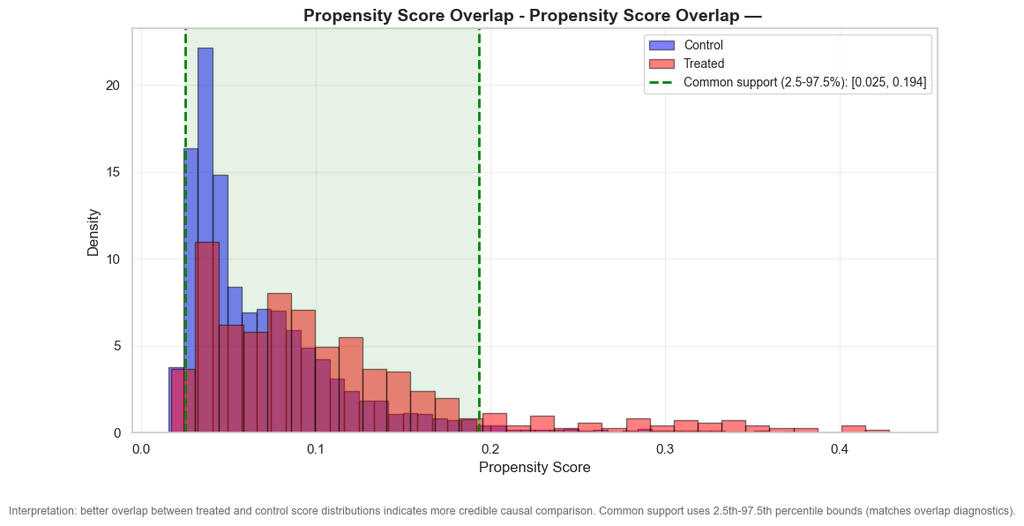

```
  ✓ Post-weighting balance: all 31 covariates balanced (|SMD| < 0.1)
```

[output not shown]

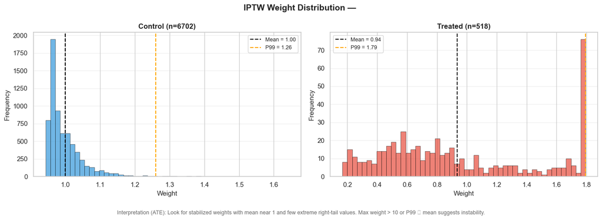

#### Fit IPTW-weighted KM curves

```
============================================================
IPTW-WEIGHTED KAPLAN-MEIER SURVIVAL CURVES
============================================================
  Treated   : n = 518, events = 80
  Control   : n = 6,702, events = 1644

  Survival Probability Snapshots:
 timepoint_days timepoint_label  survival_treated  survival_control  survival_diff
             90             3mo            0.9527            0.8800         0.0727
            180             6mo            0.9268            0.8305         0.0963
            270             9mo            0.8874            0.7934         0.0940
            365            365d            0.8278            0.7545         0.0732

  Note: KM confidence bands are NOT valid under IPTW
  (Greenwood variance ignores propensity score uncertainty).
  Use Cox PH for formal inference.
============================================================
```

[figure not shown]

#### Compute RMST difference

```
============================================================
RESTRICTED MEAN SURVIVAL TIME (RMST) ANALYSIS
============================================================
Analysis window: 365 days (12 months)
Bootstrap samples: 500

RMST ESTIMATES:
  Trained managers:    334.9 days
  Untrained managers:  307.6 days
  Difference:          +27.4 days

STATISTICAL INFERENCE:
  95% Confidence Interval: [+18.4, +35.0] days
  ✓ Statistically significant (CI excludes 0)

BUSINESS INTERPRETATION:
  Training extends retention by an average of 27.4 days
  within the 12-month study window.
  This represents:
    • 3.9 additional weeks of retention
    • 0.9 additional months of retention
    • 7.5% of the study year

METHODOLOGICAL NOTES:
  • RMST is robust to time-varying treatment effects
  • Confidence interval computed via 500-sample bootstrap
  • IPTW weights account for selection bias in training assignment
============================================================
```

#### Estimate Cox PH Model and test whether PH assumption holds

```
============================================================
COX PROPORTIONAL HAZARDS MODEL — STANDARD (NO TIME INTERACTION)
============================================================
Model            : treatment (single overall HR)

Model fitted     : 7,220 observations, 1724 events
Concordance      : 0.546

--- Proportional Hazards Test ---
NOTE: Standard Cox PH assumes proportional hazards.
      If treatment violates PH, consider re-running with
      time_interaction='categorical' to model time-varying effects.
                                   test_statistic         p note
age                                      0.830619  0.362094
gender_Male                              0.529215  0.466937
gender_Non_Binary_Other                  0.626025  0.428817
job_family_Communications                0.004071  0.949127
job_family_Data_Science                  1.119695  0.289984
job_family_Finance_and_Accounting        0.295210  0.586901
job_family_Human_Resources               1.030406  0.310063
job_family_IT_and_Digital                0.844943  0.357987
job_family_Legal_and_Compliance          3.562637  0.059094
job_family_Market_Access                 0.018959  0.890485
job_family_Marketing                     2.170828  0.140650
job_family_Medical_Affairs               0.609572  0.434949
job_family_Pharmacovigilance             0.076083  0.782677
job_family_Quality_Assurance             0.878403  0.348640
job_family_Regulatory_Affairs            1.285349  0.256907
job_family_Sales                         0.265162  0.606596
job_family_Supply_Chain                  0.079636  0.777792
num_direct_reports                       1.031454  0.309817
organization_Digital                     0.126918  0.721649
organization_Finance                     3.797846  0.051319
organization_HR                          1.807101  0.178856
organization_Manufacturing               5.555992  0.018418
organization_RandD                       0.000644  0.979747
performance_rating_Far_Exceeds           4.715630  0.029890
performance_rating_Meets                 0.039123  0.843205
region_Europe                            0.019623  0.888596
region_Latin_America                     0.203169  0.652175
region_Middle_East_and_Africa            2.833732  0.092304
region_North_America                     0.011576  0.914318
tenure_months                            0.034435  0.852784
tot_span_of_control                      0.262964  0.608091
treatment                               11.770372  0.000602

  ⚠️  Treatment variable VIOLATES proportional hazards assumption.
      The single HR may be misleading. Consider re-running with
      time_interaction='categorical'.
```

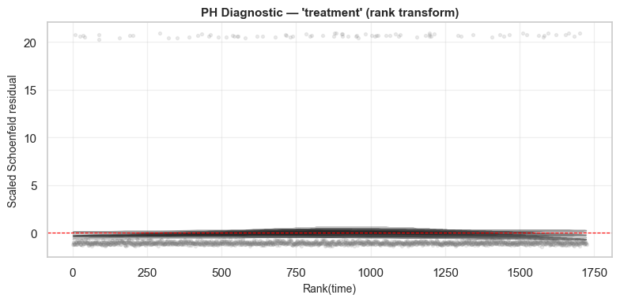

```
--- Hazard Ratios ---
 period timepoint_days  hazard_ratio  hr_ci_lower  hr_ci_upper  p_value  log_hr  se_log_hr                                    note
overall           None        0.6536        0.519        0.823   0.0003 -0.4253     0.1176 single overall HR (no time interaction)
============================================================
```

[output not shown]

**Note on E-values for survival outcomes:** The E-value is computed on the overall hazard ratio from the IPTW-weighted standard Cox model (HR = 0.654). A confounder like pre-existing intent to stay — which plausibly has an association of at least RR ≈ 1.5 with treatment (stayers more likely to enroll) and a protective association of RR ≈ 0.67 or stronger with departure (stayers less likely to leave; on the log-RR scale this is the same strength as 1.5) — could explain the retention finding at the confidence-interval bound (E-value CI bound = 1.73). This should be transparently communicated to stakeholders. Note also that the Schoenfeld residual test rejects proportional hazards for treatment (p ≈ 0.0006), so the overall HR averages a strong early effect with a null later effect — the period-specific table below is the more faithful characterisation of *when* the program matters.

```
============================================================
COX PROPORTIONAL HAZARDS MODEL — TIME INTERACTION
Interaction type : categorical
============================================================
Period breaks    : [0, 90, 180, 270, 365] (days)
Period labels    : ['0-3mo', '3-6mo', '6-9mo', '9-12mo']
Expanding to person-period format...
  Expanded from 7220 persons to 25439 person-periods
Reference period : 0-3mo

Model fitted     : 25,439 observations, 1724 events
Concordance      : 0.645

--- Proportional Hazards Test ---
NOTE: PH test is SKIPPED for time-interaction models.
      The person-period expanded data violates the independence
      assumption of the Schoenfeld residual test (same person
      contributes multiple rows), inflating test statistics.
      The time interaction model handles non-proportionality
      by design — no PH test is needed.

--- Hazard Ratios ---
period  timepoint_days  hazard_ratio  hr_ci_lower  hr_ci_upper  p_value  log_hr  se_log_hr                                           note
 0-3mo              90        0.3674       0.2363       0.5712   0.0000 -1.0014     0.2252 reference period (timepoint_days = period end)
 3-6mo             180        0.4779       0.2721       0.8393   0.0102 -0.7383     0.2873
 6-9mo             270        0.9523       0.5976       1.5176   0.8372 -0.0488     0.2378
9-12mo             365        1.3689       0.9321       2.0104   0.1092  0.3140     0.1961
============================================================
Period-Specific Hazard Ratios:
```

|  | period | timepoint_days | hazard_ratio | hr_ci_lower | hr_ci_upper | p_value | log_hr | se_log_hr | note |
| --- | --- | --- | --- | --- | --- | --- | --- | --- | --- |
| 0 | 0-3mo | 90 | 0.3674 | 0.2363 | 0.5712 | 0.0000 | -1.0014 | 0.2252 | reference period (timepoint_days = period end) |
| 1 | 3-6mo | 180 | 0.4779 | 0.2721 | 0.8393 | 0.0102 | -0.7383 | 0.2873 |  |
| 2 | 6-9mo | 270 | 0.9523 | 0.5976 | 1.5176 | 0.8372 | -0.0488 | 0.2378 |  |
| 3 | 9-12mo | 365 | 1.3689 | 0.9321 | 2.0104 | 0.1092 | 0.3140 | 0.1961 |  |

```
Concordance: 0.645
```

#### Technical Summary — Retention (Survival)

Note: Results do not generalize to poor performers.

> **Method**: IPTW-weighted survival analysis. IPTW-weighted Kaplan–Meier curves are used **descriptively / for exploration** — to visualize the shape of the retention gap over time; the snapshot differences below are reported without confidence intervals and are not the inferential target. The two formal causal estimands in this analysis are (1) the **RMST difference** — IPTW-weighted with a bootstrap CI, the stakeholder-friendly summary — and (2) the **Cox proportional hazards model** — the inferential workhorse, reported both as a single overall HR and as period-specific HRs via time interactions. Period-specific HRs characterize *when* the effect occurs but are subject to built-in survivor selection at later time points.

##### Exploratory: Survival Probability Differences (IPTW-Weighted KM)

[output not shown]

These snapshot differences are **descriptive** — shown without confidence intervals or formal inference. Under IPTW assumptions they *can* be read as the population-level difference in retention if everyone were trained vs. no one, but the inferential estimands in this analysis are the **RMST difference** and the **Cox hazard ratios** below.

##### Primary Causal Estimand: RMST Difference

Training retains managers an average of approximately **27.4 additional days** within the 12-month study window (95% CI: [18.4, 35.0] days, bootstrap n=500). This translates to roughly 3.9 additional weeks per trained manager (~390 weeks if we train 100 managers).

##### Inferential Model: Cox PH — Overall and Period-Specific Hazard Ratios

The primary Cox model reported in the notebook uses a **single overall hazard ratio** (standard proportional hazards). However, the Schoenfeld residual test rejects proportional hazards for treatment (p ≈ 0.0006), so the single overall HR averages a strong early effect with a null late effect. The time-interaction specification below characterises *when* the program matters — and makes clear that the causal benefit is concentrated in the first 3–6 months.

| Period | HR | 95% CI | p-value | Sig? |
| --- | --- | --- | --- | --- |
| 0–3 months | **0.37** | [0.24, 0.57] | < 0.0001 | Yes *** |
| 3–6 months | **0.48** | [0.27, 0.84] | 0.010 | Yes * |
| 6–9 months | 0.95 | [0.60, 1.52] | 0.84 | No |
| 9–12 months | 1.37 | [0.93, 2.01] | 0.11 | No (ns) |
| Overall (standard Cox) | 0.65 | [0.52, 0.82] | 0.0003 | Yes *** |

**Interpretation:** Trained managers have roughly **63% lower hazard of departure in the first 3 months** (HR = 0.37) and a smaller but still significant advantage in months 3–6 (HR = 0.48). After 6 months the period-specific HRs are statistically indistinguishable from 1.0 — the program does not appear to keep providing new retention benefit in the second half of the year. IPTW-weighted survival gaps by month (table above) describe *how much* retention differs at each snapshot; they do not suffer from the same interpretation issues as late-period HRs from a split-time model (which are subject to survivor selection).

##### E-Value Sensitivity Analysis

| Outcome | E-Value Point | E-Value CI | Robustness |
| --- | --- | --- | --- |
| Manager Retention | **2.43** | **1.73** | Moderate |

The E-value CI bound of 1.73 means a confounder like **pre-existing intent to stay** — which plausibly has an association of at least RR ≈ 1.5 with treatment participation (stayers more likely to enroll) and a protective association of RR ≈ 0.67 or stronger with departure risk (stayers less likely to leave; on the log-RR scale this is the same strength as 1.5) — could explain the retention finding at the conservative CI bound. This should be acknowledged when presenting results.

##### Post-Weighting Balance Verification

- ✅ Balance verification passed (0 imbalanced covariates).

### Summary: Checkpoint 4

[figure not shown]

Checkpoint 4

Retention Survival Analysis

Achievements

✅ Used IPTW-weighted KM Curves to compare retention trends

✅ Used RMST to get a business-friendly metric of retention differences

✅ Modeled hazard ratios with Cox PH model

Takeaways

**We see evidence of overall higher retention within the 12 months following the program.**

**Pre-existing intent to stay could explain this finding (people planning to leave in the next 3-6 months do not sign up for training)**

1 / 1

# What We Found

## ✅ Evidence of Program Value

### Survey Outcomes:

- Trained managers score **~12% higher on the Manager Efficacy Index**
  - Strongest and most robust finding in this analysis
  - ATE = +0.40, Cohen's d = 0.47, p < 0.0001
- Training does **not appear to add to perceived workload**
  - ATE ≈ 0, p = 0.86
  - Important "no harm" finding
- Trained managers score **~6% higher on the Stay Intention Index**
  - ATE = +0.17, Cohen's d = 0.16, p = 0.0001
  - More modest effect than efficacy
  - Should be interpreted cautiously (see retention note below)

## ⚠️ Important Caveats

### On the survey findings:

- These are **self-reported outcomes** from managers who know they participated
- Potential sources of bias:
  - Demand characteristics (responding as expected)
  - Cognitive dissonance reduction (justifying time invested)
  - Social desirability bias (wanting to appear competent)
- The efficacy finding (d = 0.47) is consistent with a real effect
- **A meaningful placebo component cannot be ruled out**

### On the retention finding:

- Participation was **voluntary and open enrollment**
- Managers who signed up may have already been more committed to staying
- **The retention gap may partly reflect who chose to participate, not just what the training did**
- IPTW approach adjusts for observed differences between groups
- Pre-existing intent to stay is **not directly measured** in this dataset

### E-value interpretation:

- Confidence-interval bound E-value for retention: **1.73**
- This means a confounder with RR ≈ 1.7 with treatment participation (stayers more likely to enroll) and a protective RR ≈ 0.59 or stronger with departure risk (stayers less likely to leave; on the log-RR scale this is the same magnitude) could explain the retention finding
- Plausible example: pre-existing intent to stay
- **Does not invalidate the finding, but warrants transparency with stakeholders**

## Robustness Summary

| Outcome | Effect | E-Value (Point) | E-Value (CI Bound) | Robustness |
| --- | --- | --- | --- | --- |
| Manager Efficacy Index | +0.40 (d = 0.47) | 2.45 | 2.18 | Moderate |
| Workload Index | ~0 (ns) | — | — | N/A |
| Stay Intention Index | +0.17 (d = 0.16) | 1.59 | 1.38 | Weak |
| Retention | +27.4 days RMST (primary); HR ≈ 0.37 in 0–3 mo, 0.48 in 3–6 mo | 2.43* | 1.73* | Moderate |

* Retention E-values are computed from the **overall** Cox HR (0.65, 95% CI [0.52, 0.82]), which time-averages a strong early effect with a null late effect (PH violated, Schoenfeld p ≈ 0.0006). They therefore characterize the robustness of the aggregate effect rather than of any single sub-period HR.

### Key takeaways from robustness analysis:

- **Efficacy finding is the most robust** result in this analysis
- **Stay intention and retention findings** are directionally consistent but more susceptible to unmeasured confounding

## What This Means

### The clearest signal:

- Training is associated with **meaningful improvements in how managers perceive their own leadership capabilities**
- This is the finding we can speak to with the **most confidence**

### A consistent but uncertain picture on retention:

- Trained managers **do appear to stay longer**
- Magnitude is **practically meaningful**
- **Cannot rule out** the possibility that managers already planning to stay were simply more likely to sign up
- Retention finding is **worth monitoring and investigating further**
- **Not strong enough to anchor a business case on its own**

## Recommendations

### 1. Invest in the Program — With Realistic Expectations

- Evidence supports **continued investment** in the training program
- Primary basis: the **efficacy finding**
- Improved manager confidence is a **meaningful outcome in its own right**
- Retention signal is **directionally positive but uncertain**
- **Avoid overstating the retention impact** in stakeholder communications

### 2. Strengthen the Evaluation Design Going Forward

Most important next step: improve ability to make causal claims about the program

**Consider:**

- explore pre- / post- testing, quasi-experimental designs (such as staggered roll-out), and alternative outcome measures (such as 360 feedback, spillover effects to direct reports, team productivity measures)
- Exploring whether any **natural variation in program rollout** (e.g., timing differences across departments) could support stronger identification strategy
- Tracking outcomes over a **longer horizon** to assess whether efficacy gains translate to sustained behavioral change

### 3. Explore Who Benefits Most

- Before scaling broadly, understand whether certain subgroups show **stronger or weaker responses**
- Subgroups to examine:
  - By tenure
  - By team size
  - By organization
- Benefits:
  - Improve targeting
  - Inform program design

### 4. Pair Training with Complementary Supports

- Training alone is **unlikely to drive long-term retention** at scale
- To maximize value of efficacy gains:
  - Pair with **structured follow-up** (check-ins, peer communities)
  - Address **systemic factors** that training does not directly address:
    - Workload
    - Career development
    - Recognition

## Bottom Line

### The evidence:

- Training program shows **credible evidence of value**
- **Most clearly** in improving manager self-efficacy
- Retention finding is **encouraging but preliminary**
- **Subject to self-selection concerns**
- **Not a confirmed causal effect**

### The recommendation:

- **Continue the program**
- **Invest in more rigorous evaluation design**
- Better isolate causal impact on retention over time

### Summary: Checkpoint 5

[figure not shown]

Checkpoint 5

Reporting & Recommendations

Achievements

✅ Delivered a statistically sound, stakeholder-friendly summary of all analyses with actionable recommendations for the L&D team

Takeaways

**Early evidence supports program value** for manager efficacy, but training alone is **unlikely to drive long-term retention** at scale.

**Opportunity ahead:** Expand analysis to additional outcomes and partner with L&D to build a **robust (quasi-)experimental strategy** aligned to their program roadmap.

1 / 1

## Bonus: Further Learning

**Linear Double Machine Learning (DML) and Estimating Heterogeneous Treatment Effects (HTE)**

[figure not shown]

### 1. Alternative ATE Estimation via Linear DML

Overview

Double Machine Learning (DML): ATE Validation

**DML** provides an alternative to IPTW for estimating the Average Treatment Effect. Instead of propensity weighting, it uses flexible machine learning to control for confounders.

**Key insight:** If IPTW and DML give **similar ATE estimates**, this suggests both methods are capturing the true causal effect despite using different approaches to confounder control.

Click any section below to explore:

Slide 2Why Validate with DML?

Slide 3The DML Framework

Slide 4Two-Stage Process

Slide 5DML vs. IPTW

Slide 6Implementation

Concept

Why Validate with Double Machine Learning?

IPTW gave us a credible average treatment effect — but relying on a single method has limitations.

Three Reasons to Validate with DML:

- **Robustness check:** Consistent results across methods increase confidence that the effect is real, not an artifact of one approach

- **Assumption testing:** IPTW and DML have different identifying assumptions — if both agree, it's less likely that a violated assumption is driving the result

- **Methodological flexibility:** DML uses machine learning to flexibly model confounding relationships without pre-specifying functional forms

**Key principle:** In causal inference, *convergent validity* across methods is one of the strongest signals we have. No single method is definitive — agreement across methods is.

**What to watch for:** If DML and IPTW produce similar ATEs, that's reassuring. If they diverge, that's a signal to investigate — not a reason to pick the more favorable result.

Framework

The Double Machine Learning Framework

DML addresses a fundamental challenge in causal inference: **regularization bias**. When using flexible ML models to control for confounders, the regularization can bias the treatment effect estimate.

The Problem:

- ML models use regularization (e.g., in Random Forest, Lasso) to prevent overfitting

- This regularization can **shrink the treatment effect estimate** toward zero

- Standard ML approaches don't provide valid statistical inference for causal effects

DML's Solution:

- **Two-stage process:** Separate nuisance function estimation from causal effect estimation

- **Cross-fitting:** Estimate nuisance functions on independent data splits

- **Neyman-orthogonal scores:** Make the final estimate insensitive to small errors in ML predictions

**Result:** √n-consistent and asymptotically normal treatment effect estimates, even with flexible ML models.

**What DML-PLR assumes:** The partially linear model `Y = β·T + g(X) + ε` treats the treatment effect as *homogeneous* on the additive scale — a single β applies to every unit. If you suspect the effect varies across managers (heterogeneity), use the **Causal Forest** (bonus section), which relaxes this to `Y = τ(X)·T + g(X) + ε`.

Process

DML's Two-Stage Process

🎯 Stage 1: Nuisance Function Estimation

- Fit ML models to predict the outcome: \(\hat{m}(X) = E[Y \mid X]\)

- Fit ML models to predict treatment: \(\hat{e}(X) = E[T \mid X]\)

- Use **cross-fitting** — split data into folds, train on some folds, predict on others

🎯 Stage 2: Debiased Causal Effect Estimation

- Compute **Neyman-orthogonal scores** using residuals from Stage 1

- Solve for \(\theta\) (the treatment effect) by setting the sample average of scores to zero

**Neyman-orthogonal score:**  
\(\psi(W_i; \theta) = (Y_i - \hat{m}(X_i)) \cdot (T_i - \hat{e}(X_i)) - \theta \cdot (T_i - \hat{e}(X_i))^2\)  
**Solve:** \(\frac{1}{n}\sum_i \psi(W_i; \theta) = 0\)

Why this works:

- The orthogonal score is **insensitive to small errors** in \(\hat{m}\) and \(\hat{e}\)

- Cross-fitting ensures nuisance functions are estimated on independent data

- Result: Valid inference despite using flexible ML models

Comparison

DML vs. IPTW + GEE

| Aspect | IPTW + GEE | Linear DML |
| --- | --- | --- |
| **Confounder Control** | Propensity score weighting | ML-based nuisance function estimation |
| **Final Model** | Weighted GEE regression | Neyman-orthogonal moment conditions |
| **Clustering** | ✅ Cluster-robust sandwich SEs | ✅ Cluster-aware cross-fitting + cluster-robust SEs |
| **Flexibility** | Linear propensity score model | ✅ Flexible ML models (Random Forest) |
| **Use Case** | Primary analysis with clustering | Robustness check, method validation |

**Convergent validity:** If both methods produce similar ATE estimates, this strengthens confidence that we're capturing the true causal effect — each method has different assumptions and potential failure modes.

Implementation

Implementation Notes

We use the `doubleml` package (Bach et al., 2022) for DML estimation with cluster-robust inference:

Key Features:

- **Native cluster-robust inference:** Automatically handles clustering at the team level

- **Cluster-aware cross-fitting:** Ensures clusters aren't split across training/prediction folds

- **Flexible ML backends:** Supports Random Forest, Lasso, and other learners

- **Automatic standard errors:** Cluster-robust sandwich SEs computed automatically

**Why cluster-aware cross-fitting?** If we split data at the individual level, we might train on some managers from a team and predict on others from the same team. This violates the independence assumption. Cluster-aware splitting keeps entire teams together.

**Cluster specification:** When `cluster_cols` is specified in `doubleml`, cluster-aware cross-fitting and cluster-robust standard errors are handled automatically — no additional configuration needed.

1 / 6

#### Run DML

```
============================================================
CLUSTER-ROBUST DML — ATE ESTIMATION: manager_efficacy_index
============================================================

  DoubleML PLR - Cluster-Robust ATE Estimation
  ==================================================
  ATE = 0.3838 (SE = 0.0342, 1079 clusters)
  95% CI: [0.3167, 0.4509]
  p-value = 0.0000 ***
  n = 6044
  Inference: cluster-robust (cluster_cols = 'team_id')
  ==================================================

  [manager_efficacy_index] Method Comparison:
    IPTW+GEE (cluster-robust):  ATE = 0.3975  CI: [0.3222, 0.4729]
    DoubleML (cluster-robust): ATE = 0.3838  CI: [0.3167, 0.4509]
    Difference in point estimates: 0.0137
```

#### DML Technical Summary: Manager Efficacy

Note: Findings do not generalize to poor performers, who were excluded earlier in the analysis.

> **Method**: Cluster-robust Double Machine Learning (Partially Linear Regression) via `doubleml`. Nuisance models (outcome, treatment) are residualized using flexible learners and cross-fitted with cluster-aware folds; the final ATE is estimated on the residualized targets with cluster-robust standard errors (`cluster_cols = 'team_id'`). This makes the DML vs. IPTW+GEE comparison apples-to-apples — both estimators now account for team-level clustering.

##### Cluster-Robust ATE

| Estimator | ATE | SE | 95% CI | p-value | n | Clusters |
| --- | --- | --- | --- | --- | --- | --- |
| DoubleML PLR | **+0.38** | 0.034 | [0.32, 0.45] | < 0.0001 | 6,044 | 1,079 |

**Interpretation**: The cluster-robust DML estimate (+0.38, 95% CI [0.32, 0.45]) is directionally and practically consistent with the primary IPTW+GEE estimate (+0.40, 95% CI [0.32, 0.47]); the two point estimates differ by only ~0.01 on the outcome scale. The agreement across two fundamentally different strategies — propensity-score reweighting vs. residualization-based ML — increases confidence that the manager-efficacy effect reflects a genuine treatment impact rather than an artifact of a single modeling approach.

##### Caveats

- DML reports a **single average treatment effect**; it does not answer *who* benefits more or less. The heterogeneity question is addressed by the Causal Forest below.
- The DML confidence interval may differ slightly in width from the IPTW+GEE CI. This reflects different variance estimation approaches (score-based vs. sandwich), not a meaningful methodological disagreement.
- Minor numerical differences between the DML point estimate and IPTW+GEE estimate are expected because the two estimators residualize vs. reweight to identify the same target; they converge in expectation but not sample-by-sample.

### 2. Heterogeneous Treatment Effects (HTE)

Bonus Checkpoint

Exploring Heterogeneous Treatment Effects (HTE)

After presenting your results, stakeholders often ask: **"Does the training work better or worse for certain groups?"**

**This is exploratory analysis:** We're using CATE (Conditional Average Treatment Effects) to generate hypotheses about who benefits most — not to prove definitive conclusions. These patterns should inform future evaluation when the L&D team refines or scales the program.

Click any section below to explore:

Slide 2Why Explore Heterogeneity?

Slide 3Domain-Driven Exploration

Slide 4CATE via Causal Forest

Slide 5Interpreting Results

Slide 6Communicating Findings

Why HTE?

Why Explore Heterogeneity?

An average treatment effect tells you the program works *on average*. But averages can mask important variation across individuals.

Four Business Reasons to Explore HTE:

- **🎯 Future Targeting:** Identify which groups might benefit most when the program scales

- **🔧 Program Refinement:** Generate hypotheses about how to tailor content for different subgroups

- **⚖️ Equity Insights:** Understand whether benefits are distributed evenly or concentrated in certain groups

- **🔍 Mechanism Discovery:** Understanding *who* benefits can reveal *why* the program works

**Critical caveat:** This is **hypothesis-generating**, not hypothesis-testing. Patterns we find here should be validated in future evaluations with pre-registered hypotheses and new data.

Framework

Domain-Driven Exploration: Constraining the Search Space

The key to responsible HTE exploration is **constraining which variables we examine** based on theory and context — not fishing across everything.

Before Running CATE, Ask:

- **What does the intervention design suggest?** Which characteristics are theoretically relevant to how the training works?

- **What does organizational context tell us?** Which variables matter for practical decision-making?

- **What can we actually act on?** Focus on variables that inform future program design or targeting

🔍 Our Approach: Structured, Theory-Guided Exploration

- **Pre-specify candidate moderators** based on intervention design and org context

- **Limit to 5-10 variables** with clear theoretical or practical justification

- **Document your reasoning** for why each variable matters before looking at results

- **Report what you looked at** — not just what "worked"

**Example:** For manager training, we might explore: tenure (new managers may need more support), team size (span of control affects application), organization (different cultures/contexts), and prior performance (ceiling effects).

Method

CATE Exploration via Causal Forest

**Causal Forest** is a machine learning method that estimates individualized treatment effects and identifies which variables best predict who benefits more vs. less.

What Causal Forest Does:

- **Individual effects:** Estimates a personalized treatment effect for each person based on their characteristics

- **Feature importance:** Ranks your pre-specified variables by their ability to predict heterogeneity

- **Pattern discovery:** Finds complex, non-linear relationships without requiring you to specify functional forms

Key Outputs for Exploration:

- **CATE distribution:** Shows the range of individual treatment effects across the population

- **Feature importance plot:** Identifies which of your candidate variables matter most for heterogeneity

- **Subgroup patterns:** Reveals where the biggest differences in treatment response occur

**Important limitation:** High feature importance doesn't prove causation. Variables can rank highly due to spurious correlations, sample imbalances, or overfitting. These are *patterns worth investigating*, not proven facts.

**Think of CATE as:** A sophisticated exploratory tool that tells you *where to look* for heterogeneity in future studies — not what to conclude from this one.

Interpretation

Interpreting CATE Results Responsibly

How you interpret and communicate CATE findings determines whether this analysis is useful or misleading.

What CATE Results Tell You:

- **Patterns worth investigating:** "Team size appears to moderate effects — worth testing in future evaluations"

- **Hypothesis generation:** "New managers may benefit more — this could inform targeting when we scale"

- **Approximate effect sizes:** "Effects range from X to Y across individuals, with most clustering around Z"

- **Variables that don't matter:** "No clear patterns for role type or organization in this sample"

What CATE Results DON'T Tell You:

- ❌ **Proven causal relationships:** Feature importance ≠ confirmed moderator

- ❌ **Precise cutoffs:** "Team size > 12" is data-driven and sample-specific, not a universal threshold

- ❌ **Definitive targeting rules:** "Only train large teams" would be over-interpreting exploratory findings

- ❌ **Statistical significance:** P-values from data-driven specifications are biased

**The core methodological risk:** Any data-informed analytical choice (CATE, eyeballing plots, etc.) introduces bias into p-values. These are exploratory, not confirmatory — they don't mean what classical hypothesis tests mean.

**Validation requires new data:** To confirm these patterns, you'd need to pre-register hypotheses (e.g., "training works better for managers of large teams") and test them in a future evaluation when the program is refined or scaled.

Communication

Communicating CATE Findings to Stakeholders

How you frame results determines whether stakeholders use them appropriately or over-interpret them.

Good Framing (Hypothesis-Generating):

- ✅ "Our exploratory analysis suggests team size may moderate effects — worth investigating when you refine the program"

- ✅ "We see patterns suggesting new managers benefit more, but we'd want to validate this in future data"

- ✅ "Effects appear consistent across organizations in this sample, though sample sizes vary"

- ✅ "No strong heterogeneity detected for role type — the program seems to work similarly across roles"

Bad Framing (Over-Interpretation):

- ❌ "We proved that training only works for teams larger than 12"

- ❌ "You should target new managers because they benefit significantly more (p < 0.05)"

- ❌ "The data shows experienced managers don't benefit, so exclude them"

- ❌ Presenting CATE-derived cutoffs as if they were pre-specified hypotheses

**Recommended framing template:**  
"Our exploratory analysis identified [pattern] as worth investigating further. This is hypothesis-generating — we searched across [X variables] justified by [theory/context]. To confirm this pattern, we'd recommend pre-registering it as a hypothesis when the L&D team [refines/scales] the program and testing it in new data."

Always Include These Caveats:

- These patterns are exploratory and hypothesis-generating

- Cutoffs are data-driven and sample-specific (approximate, not precise)

- Proper validation requires new data with pre-registered hypotheses

- Report what you looked at, not just what "worked"

**Positioning for action:** Frame findings as informing *future* decisions: "When you scale this program, consider testing whether [pattern] holds — that would let us optimize targeting and resource allocation."

1 / 6

#### Run Causal Forest

```
============================================================
HTE — CAUSAL FOREST CATE: manager_efficacy_index
============================================================

  Fitting Causal Forest DML for 'manager_efficacy_index'...
Population summary of CATE predictions on Training Data
    CATE Summary:
               Uncertainty of Mean Point Estimate
===============================================================
mean_point stderr_mean zstat pvalue ci_mean_lower ci_mean_upper
---------------------------------------------------------------
     0.379       0.198 1.911  0.056         -0.01         0.768
      Distribution of Point Estimate
=========================================
std_point pct_point_lower pct_point_upper
-----------------------------------------
    0.133            0.12           0.642
     Total Variance of Point Estimate
==========================================
stderr_point ci_point_lower ci_point_upper
------------------------------------------
       0.239         -0.101           0.85
       Doubly Robust ATE on Training Data Results
========================================================
    point_estimate stderr zstat pvalue ci_lower ci_upper
--------------------------------------------------------
ATE          0.486  0.098 4.972    0.0    0.294    0.678
     Doubly Robust ATT(T=0) on Training Data Results
=========================================================
    point_estimate stderr zstat  pvalue ci_lower ci_upper
---------------------------------------------------------
ATT          0.376  0.012 31.809    0.0    0.353    0.399
    Doubly Robust ATT(T=1) on Training Data Results
========================================================
    point_estimate stderr zstat pvalue ci_lower ci_upper
--------------------------------------------------------
ATT          1.762  1.218 1.446  0.148   -0.626    4.149
--------------------------------------------------------

Note: The stderr_mean is a conservative upper bound.
    ATE (Causal Forest) = 0.3807, 95% CI: [0.0052, 0.7562]

  [manager_efficacy_index] DML ATE = 0.3807 (95% CI: [0.0052, 0.7562]), p = 0.0888 , Cohen's d = 0.4359
  Results saved to c:\Users\U1013877\OneDrive - Sanofi\Documents\GitHub\2026-siop-causal-inference-master-tutorial\results/dml_ate_HTE_manager_efficacy_index.xlsx
```

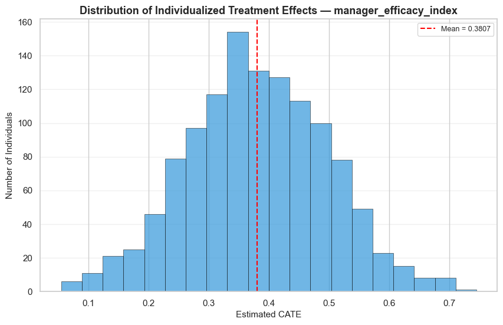

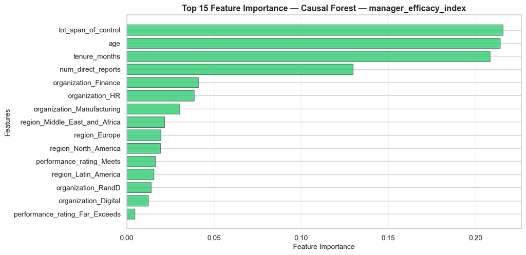

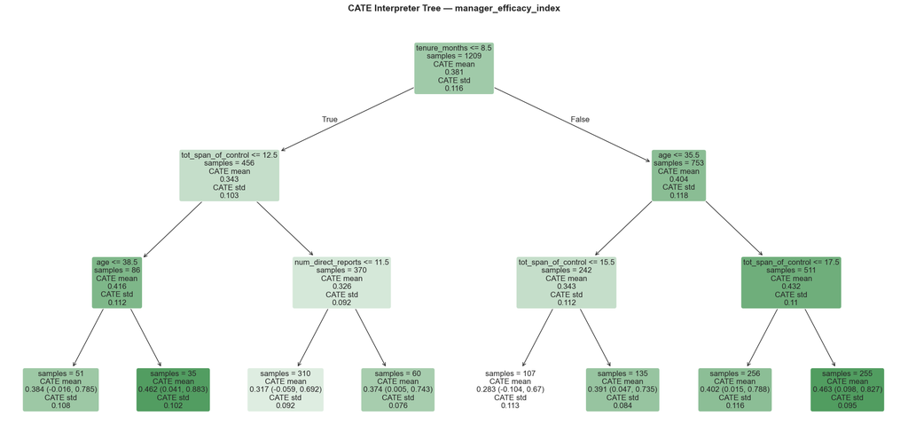

#### HTE Technical Summary: Manager Efficacy

Note: Findings do not generalize to poor performers, who were excluded earlier in the analysis.

> **Method**: Causal Forest via Double Machine Learning (`econml.CausalForestDML`) estimates a **Conditional Average Treatment Effect (CATE)** for every manager — i.e., *who* benefits more or less, rather than a single population-level average. The **full covariate set** (categorical + continuous) is used as confounding controls (W); only a **theory-motivated, actionable slice** is used as potential effect modifiers (X): `organization`, `performance_rating`, `region`, `age`, `tenure_months`, `num_direct_reports`, and `tot_span_of_control`. `gender` and `job_family` are intentionally excluded from X to avoid surfacing fairness-sensitive or high-cardinality noisy moderators. Positivity for `performance_rating` holds because Below / Far Below were excluded from the analytic sample earlier in the notebook.

> **What this adds beyond DML**: DML above answers *"is there an average effect?"*. The Causal Forest answers *"does the effect vary across managers, and if so, along which actionable dimensions?"*. As a sanity check, the forest's doubly-robust marginal ATE (**+0.38**, 95% CI [0.01, 0.76]) is directionally consistent with the DoubleML PLR ATE (**+0.38**) and the IPTW+GEE ATE (**+0.40**). The wider CI (lower bound 0.01) reflects the price of flexibility — the forest estimates an individualized CATE function, which costs marginal precision. Importantly, the forest's 95% CI on the marginal effect is *nearly* inclusive of zero; treat the agreement across methods as qualitative convergence, not a tight replication.

##### Effect Modifier Feature Importance

[output not shown]

### 3. Agentic Workflow

- If you are curious about agentic AI or are familiar with AI coding assistants such as Github Copilot, Cursor, or Claude Code, then you may be interested in how agentic workflows can augment the analysis process.
- This repo contains an experimental agent for causal inference: ./casaul_inference_ai_agentic_workflow.
- Please see ./references_and_further_learning/AI Agentic Workflow for Causal Inference.pdf for an introduction to this agent.

[figure not shown]

Bonus Content

Advanced Methods & Heterogeneous Effects

Achievements

✅ Estimated ATE with Double Machine Learning

✅ Explored heterogeneous treatment effects with CATE using causal forest

Takeaways

**Double Machine Learning** provides a robustness check on our original model by using flexible machine learning to control for confounders, offering **convergent validity** when results align across methods.

Analyzing **heterogeneous treatment effects** provides exploratory insights into program impact, such as **identifying which groups may benefit more or less** — though these patterns should be validated in future data with pre-registered hypotheses.

**Agentic AI** can be a tool to help structure and execute analyses, but is not a replacement for thorough causal inference knowledge.

1 / 1

## Further Reading + Workshop Summary

Overview

Causal Inference Analysis: Complete Journey

Navigate through our complete causal inference analysis from research design to advanced methods. Click any section below to jump to it:

Slide 2Learning Resources

Slide 3Checkpoint 1: Research Design

Slide 4Checkpoint 2: Diagnostics

Slide 5Checkpoint 3: Survey Modeling

Slide 6Checkpoint 4: Retention Modeling

Slide 7Checkpoint 5: Final Recommendations

Slide 8Bonus: Further Learning

Resources

Quick Links to Our Favorite Learning Resources

See **references_and_further_learning/reading_list_by_topic.docx** for full list

Essential Resources:

[**DAGitty** Interactive tool for learning and building Directed Acyclic Graphs (DAGs)](https://www.dagitty.net/) [**The Causal Mindset Handbook** Comprehensive guide to causal thinking and methodology](https://thecausalmindset.com/book) [**The Book of Why** Judea Pearl's accessible introduction to causal reasoning](https://danamackenzie.com/books/the-book-of-why/)

[figure not shown]

Checkpoint 1

Research Design & Data Exploration

Achievements

✅ Documented assumptions with a DAG aligned to our research question

✅ Conducted best practice data hygiene checks and exploratory analysis

Key Research Questions

Does manager training impact **self-reported efficacy, workload, or stay intention**? Does it impact **actual retention**?

Takeaways

**Clean data:** No missing data, no repeats, no improbable values.

**Some imbalance** observed between Treatment and Control for Job Family, Organization, and Region. Control teams trend slightly larger.

**Problematic imbalance for performance:** No low-performing managers signed up for training → **low performers removed from analysis population**.

[figure not shown]

Checkpoint 2

Diagnostics & Causal Identification

Achievements

✅ Determined our estimand of interest

✅ Conducted diagnostics to assess credibility of causal inference and identify model stabilization strategies

Takeaways

After removing untreated low-performer controls, all diagnostics support a **reasonable ATE estimate**.

**No concerning multicollinearity.**

**AUC < 0.7** with ~90% overlap in both directions — observed covariates do not strongly predict treatment. This is a **necessary but not sufficient** condition for valid IPTW adjustment. Unobserved confounding is still possible and is addressed via E-value sensitivity analysis later in the workflow.

**Moderate imbalance** detected across region, performance categories, organization, and job family. Will be addressed via **IPTW + GEE**.

[figure not shown]

Checkpoint 3

Estimation & Results

Achievements

✅ Successfully used IPTW weights and sandwiched SEs to fit stable GEE models (survey outcomes) and Cox Survival model with time interactions (retention)

✅ Verified data balance and conducted sensitivity checks to confirm robustness of findings

✅ Compared ATE and ATT estimands

Takeaways

**Strongest evidence for positive effect on manager efficacy.** No effect detected for workload. Tenuous effect for stay intention.

[figure not shown]

Checkpoint 4

Retention Survival Analysis

Achievements

✅ Used IPTW-weighted KM Curves to compare retention trends

✅ Used RMST to get a business-friendly metric of retention differences

✅ Modeled hazard ratios with Cox PH with time interactions

Takeaways

**Pre-existing intent to stay could explain this finding (people planning to leave soon do not sign up for training)**

[figure not shown]

Checkpoint 5

Reporting & Recommendations

Achievements

✅ Delivered a statistically sound, stakeholder-friendly summary of all analyses with actionable recommendations for the L&D team

Takeaways

**Early evidence supports program value** for manager efficacy, but training alone is **unlikely to drive long-term retention** at scale.

**Opportunity ahead:** Expand analysis to additional outcomes and partner with L&D to build a **robust (quasi-)experimental strategy** aligned to their program roadmap.

[figure not shown]

Bonus Content

Advanced Methods & Heterogeneous Effects

Achievements

✅ Estimated ATE with Double Machine Learning

✅ Explored heterogeneous treatment effects with CATE using causal forest

Takeaways

**Double Machine Learning** provides a robustness check on our original model by using flexible machine learning to control for confounders, offering **convergent validity** when results align across methods.

Analyzing **heterogeneous treatment effects** provides exploratory insights into program impact, such as **identifying which groups may benefit more or less** — though these patterns should be validated in future data with pre-registered hypotheses.

**Agentic AI** can be a tool to help structure and execute analyses, but is not a replacement for thorough causal inference knowledge.

1 / 8